# Project: Identify Customer Segments

In this project, you will apply unsupervised learning techniques to identify segments of the population that form the core customer base for a mail-order sales company in Germany. These segments can then be used to direct marketing campaigns towards audiences that will have the highest expected rate of returns. The data that you will use has been provided by our partners at Bertelsmann Arvato Analytics, and represents a real-life data science task.

This notebook will help you complete this task by providing a framework within which you will perform your analysis steps. In each step of the project, you will see some text describing the subtask that you will perform, followed by one or more code cells for you to complete your work. **Feel free to add additional code and markdown cells as you go along so that you can explore everything in precise chunks.** The code cells provided in the base template will outline only the major tasks, and will usually not be enough to cover all of the minor tasks that comprise it.

It should be noted that while there will be precise guidelines on how you should handle certain tasks in the project, there will also be places where an exact specification is not provided. **There will be times in the project where you will need to make and justify your own decisions on how to treat the data.** These are places where there may not be only one way to handle the data. In real-life tasks, there may be many valid ways to approach an analysis task. One of the most important things you can do is clearly document your approach so that other scientists can understand the decisions you've made.

At the end of most sections, there will be a Markdown cell labeled **Discussion**. In these cells, you will report your findings for the completed section, as well as document the decisions that you made in your approach to each subtask. **Your project will be evaluated not just on the code used to complete the tasks outlined, but also your communication about your observations and conclusions at each stage.**

```python
# import libraries here; add more as necessary
import numpy as np
import pandas as pd
import matplotlib.pyplot as plt
import seaborn as sns
import random
random.seed(8)
from scipy.stats import itemfreq, chisquare

from sklearn.preprocessing import StandardScaler
from sklearn.preprocessing import Imputer
from sklearn.decomposition import PCA
from sklearn.cluster import KMeans



# magic word for producing visualizations in notebook
%matplotlib inline

'''
Import note: The classroom currently uses sklearn version 0.19.
If you need to use an imputer, it is available in sklearn.preprocessing.Imputer,
instead of sklearn.impute as in newer versions of sklearn.
'''
```

```
'\nImport note: The classroom currently uses sklearn version 0.19.\nIf you need to use an imputer, it is available in sklearn.preprocessing.Imputer,\ninstead of sklearn.impute as in newer versions of sklearn.\n'
```

### Step 0: Load the Data

There are four files associated with this project (not including this one):

Each row of the demographics files represents a single person, but also includes information outside of individuals, including information about their household, building, and neighborhood. You will use this information to cluster the general population into groups with similar demographic properties. Then, you will see how the people in the customers dataset fit into those created clusters. The hope here is that certain clusters are over-represented in the customers data, as compared to the general population; those over-represented clusters will be assumed to be part of the core userbase. This information can then be used for further applications, such as targeting for a marketing campaign.

To start off with, load in the demographics data for the general population into a pandas DataFrame, and do the same for the feature attributes summary. Note for all of the `.csv` data files in this project: they're semicolon (`;`) delimited, so you'll need an additional argument in your [`read_csv()`](https://pandas.pydata.org/pandas-docs/stable/generated/pandas.read_csv.html) call to read in the data properly. Also, considering the size of the main dataset, it may take some time for it to load completely.

Once the dataset is loaded, it's recommended that you take a little bit of time just browsing the general structure of the dataset and feature summary file. You'll be getting deep into the innards of the cleaning in the first major step of the project, so gaining some general familiarity can help you get your bearings.

```python
# Load in the general demographics data.
azdias = pd.read_csv('Udacity_AZDIAS_Subset.csv' ,sep= ';')

# Load in the feature summary file.
feat_info =pd.read_csv('AZDIAS_Feature_Summary.csv', sep = ';')
```

```python
# Check the structure of the data after it's loaded (e.g. print the number of
# rows and columns, print the first few rows).
print('azidas has {} columns and {} rows'.format(len(azdias.columns), len(azdias)))
print('feat has {} columns and {} rows'.format(len(feat_info.columns), len(feat_info)))
```

```
azidas has 85 columns and 891221 rows
feat has 4 columns and 85 rows
```

```python
# view of the data
azdias.head()
```

|  | AGER_TYP | ALTERSKATEGORIE_GROB | ANREDE_KZ | CJT_GESAMTTYP | FINANZ_MINIMALIST | FINANZ_SPARER | FINANZ_VORSORGER | FINANZ_ANLEGER | FINANZ_UNAUFFAELLIGER | FINANZ_HAUSBAUER | ... | PLZ8_ANTG1 | PLZ8_ANTG2 | PLZ8_ANTG3 | PLZ8_ANTG4 | PLZ8_BAUMAX | PLZ8_HHZ | PLZ8_GBZ | ARBEIT | ORTSGR_KLS9 | RELAT_AB |
| --- | --- | --- | --- | --- | --- | --- | --- | --- | --- | --- | --- | --- | --- | --- | --- | --- | --- | --- | --- | --- | --- |
| 0 | -1 | 2 | 1 | 2.0 | 3 | 4 | 3 | 5 | 5 | 3 | ... | NaN | NaN | NaN | NaN | NaN | NaN | NaN | NaN | NaN | NaN |
| 1 | -1 | 1 | 2 | 5.0 | 1 | 5 | 2 | 5 | 4 | 5 | ... | 2.0 | 3.0 | 2.0 | 1.0 | 1.0 | 5.0 | 4.0 | 3.0 | 5.0 | 4.0 |
| 2 | -1 | 3 | 2 | 3.0 | 1 | 4 | 1 | 2 | 3 | 5 | ... | 3.0 | 3.0 | 1.0 | 0.0 | 1.0 | 4.0 | 4.0 | 3.0 | 5.0 | 2.0 |
| 3 | 2 | 4 | 2 | 2.0 | 4 | 2 | 5 | 2 | 1 | 2 | ... | 2.0 | 2.0 | 2.0 | 0.0 | 1.0 | 3.0 | 4.0 | 2.0 | 3.0 | 3.0 |
| 4 | -1 | 3 | 1 | 5.0 | 4 | 3 | 4 | 1 | 3 | 2 | ... | 2.0 | 4.0 | 2.0 | 1.0 | 2.0 | 3.0 | 3.0 | 4.0 | 6.0 | 5.0 |

5 rows × 85 columns

> **Tip**: Add additional cells to keep everything in reasonably-sized chunks! Keyboard shortcut `esc --> a` (press escape to enter command mode, then press the 'A' key) adds a new cell before the active cell, and `esc --> b` adds a new cell after the active cell. If you need to convert an active cell to a markdown cell, use `esc --> m` and to convert to a code cell, use `esc --> y`.

## Step 1: Preprocessing

### Step 1.1: Assess Missing Data

The feature summary file contains a summary of properties for each demographics data column. You will use this file to help you make cleaning decisions during this stage of the project. First of all, you should assess the demographics data in terms of missing data. Pay attention to the following points as you perform your analysis, and take notes on what you observe. Make sure that you fill in the **Discussion** cell with your findings and decisions at the end of each step that has one!

#### Step 1.1.1: Convert Missing Value Codes to NaNs

The fourth column of the feature attributes summary (loaded in above as `feat_info`) documents the codes from the data dictionary that indicate missing or unknown data. While the file encodes this as a list (e.g. `[-1,0]`), this will get read in as a string object. You'll need to do a little bit of parsing to make use of it to identify and clean the data. Convert data that matches a 'missing' or 'unknown' value code into a numpy NaN value. You might want to see how much data takes on a 'missing' or 'unknown' code, and how much data is naturally missing, as a point of interest.

**As one more reminder, you are encouraged to add additional cells to break up your analysis into manageable chunks.**

```python
# feat_info data view
feat_info.head()
```

|  | attribute | information_level | type | missing_or_unknown |
| --- | --- | --- | --- | --- |
| 0 | AGER_TYP | person | categorical | [-1,0] |
| 1 | ALTERSKATEGORIE_GROB | person | ordinal | [-1,0,9] |
| 2 | ANREDE_KZ | person | categorical | [-1,0] |
| 3 | CJT_GESAMTTYP | person | categorical | [0] |
| 4 | FINANZ_MINIMALIST | person | ordinal | [-1] |

```python
# Transforming the 'missing_or_unknown' column from a string to a list
feat_info['missing_or_unknown'] = feat_info['missing_or_unknown'].apply(lambda x: x.strip('[]').\
                                                    split(','))
```

```python
feat_info.head()
```

|  | attribute | information_level | type | missing_or_unknown |
| --- | --- | --- | --- | --- |
| 0 | AGER_TYP | person | categorical | [-1, 0] |
| 1 | ALTERSKATEGORIE_GROB | person | ordinal | [-1, 0, 9] |
| 2 | ANREDE_KZ | person | categorical | [-1, 0] |
| 3 | CJT_GESAMTTYP | person | categorical | [0] |
| 4 | FINANZ_MINIMALIST | person | ordinal | [-1] |

```python
# Mapping all 'missing_or_unknown' values for each feature
# into the azdias dataset.
for attribute, missing_or_unknown in zip(feat_info['attribute'], feat_info['missing_or_unknown']):
    if missing_or_unknown[0] != '':
        for val in missing_or_unknown:
            if val.isnumeric() or val.lstrip('-').isnumeric():
                azdias.loc[azdias[attribute] == int(val), attribute] = np.nan
            else:
                azdias.loc[azdias[attribute] == val, attribute] = np.nan
```

#### Step 1.1.2: Assess Missing Data in Each Column

How much missing data is present in each column? There are a few columns that are outliers in terms of the proportion of values that are missing. You will want to use matplotlib's [`hist()`](https://matplotlib.org/api/_as_gen/matplotlib.pyplot.hist.html) function to visualize the distribution of missing value counts to find these columns. Identify and document these columns. While some of these columns might have justifications for keeping or re-encoding the data, for this project you should just remove them from the dataframe. (Feel free to make remarks about these outlier columns in the discussion, however!)

For the remaining features, are there any patterns in which columns have, or share, missing data?

```python
# Perform an assessment of how much missing data there is in each column of the
# dataset.
percentage_null_column = azdias.isnull().sum().reset_index()
percentage_null_column.columns = ['column', 'percentage_null']
percentage_null_column['percentage_null'] = percentage_null_column['percentage_null'].apply(lambda x: (x/len(azdias))*100)

percentage_null_column.head()
```

|  | column | percentage_null |
| --- | --- | --- |
| 0 | AGER_TYP | 76.955435 |
| 1 | ALTERSKATEGORIE_GROB | 0.323264 |
| 2 | ANREDE_KZ | 0.000000 |
| 3 | CJT_GESAMTTYP | 0.544646 |
| 4 | FINANZ_MINIMALIST | 0.000000 |

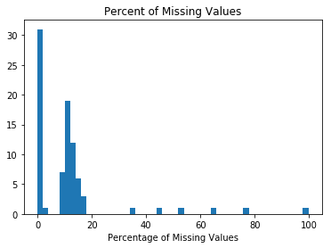

```python
# Plotting histogram of percentage of missing data in columns
plt.hist(percentage_null_column['percentage_null'], bins=50)
plt.title('Percent of Missing Values')
plt.xlabel('Percentage of Missing Values')
plt.show()
```

```python
# Investigate patterns in the amount of missing data in each column.
outlier_column_mt_20 = percentage_null_column[percentage_null_column['percentage_null']>20].copy()
```

```python
# Number of columns with > 20% missing data
len(outlier_column_mt_20)
```

```
6
```

```python
#Name of columns missing > 20% data
print(outlier_column_mt_20['column'])
```

```
0         AGER_TYP
11     GEBURTSJAHR
40        TITEL_KZ
43        ALTER_HH
47    KK_KUNDENTYP
64    KBA05_BAUMAX
Name: column, dtype: object
```

```python
outlier_column_mt_20
```

|  | column | percentage_null |
| --- | --- | --- |
| 0 | AGER_TYP | 76.955435 |
| 11 | GEBURTSJAHR | 44.020282 |
| 40 | TITEL_KZ | 99.757636 |
| 43 | ALTER_HH | 34.813699 |
| 47 | KK_KUNDENTYP | 65.596749 |
| 64 | KBA05_BAUMAX | 53.468668 |

```python
drop_columns = outlier_column_mt_20['column'].values
drop_columns
```

```
array(['AGER_TYP', 'GEBURTSJAHR', 'TITEL_KZ', 'ALTER_HH', 'KK_KUNDENTYP',
       'KBA05_BAUMAX'], dtype=object)
```

```python
# Dropping all the columns missing > 20% of data from azdias.
azdias.drop(columns = drop_columns, axis =1, inplace = True)
```

#### Discussion 1.1.2: Assess Missing Data in Each Column

The overall distribution percentage of missing data was below 20% for 79 of th 85 columns. The outliers were missing more than 20% of the data. The columns that were removed from the dataset includes:

- AGER_TYP
- GEBURTSJAHR
- TITEL_KZ
- ALTER_HH
- KK_KUNDENTYP
- KBA05_BAUMAX

#### Step 1.1.3: Assess Missing Data in Each Row

Now, you'll perform a similar assessment for the rows of the dataset. How much data is missing in each row? As with the columns, you should see some groups of points that have a very different numbers of missing values. Divide the data into two subsets: one for data points that are above some threshold for missing values, and a second subset for points below that threshold.

In order to know what to do with the outlier rows, we should see if the distribution of data values on columns that are not missing data (or are missing very little data) are similar or different between the two groups. Select at least five of these columns and compare the distribution of values.

- You can use seaborn's [`countplot()`](https://seaborn.pydata.org/generated/seaborn.countplot.html) function to create a bar chart of code frequencies and matplotlib's [`subplot()`](https://matplotlib.org/api/_as_gen/matplotlib.pyplot.subplot.html) function to put bar charts for the two subplots side by side.
- To reduce repeated code, you might want to write a function that can perform this comparison, taking as one of its arguments a column to be compared.

Depending on what you observe in your comparison, this will have implications on how you approach your conclusions later in the analysis. If the distributions of non-missing features look similar between the data with many missing values and the data with few or no missing values, then we could argue that simply dropping those points from the analysis won't present a major issue. On the other hand, if the data with many missing values looks very different from the data with few or no missing values, then we should make a note on those data as special. We'll revisit these data later on. **Either way, you should continue your analysis for now using just the subset of the data with few or no missing values.**

```python
# How much data is missing in each row of the dataset?
percentage_null_row = azdias.isnull().sum(axis =1).reset_index()
percentage_null_row.columns = ['row', 'percentage_null']
percentage_null_row['percentage_null'] = percentage_null_row['percentage_null'].apply(lambda x: x/len(azdias.columns)*100)
percentage_null_row.head()
```

|  | row | percentage_null |
| --- | --- | --- |
| 0 | 0 | 54.430380 |
| 1 | 1 | 0.000000 |
| 2 | 2 | 0.000000 |
| 3 | 3 | 8.860759 |
| 4 | 4 | 0.000000 |

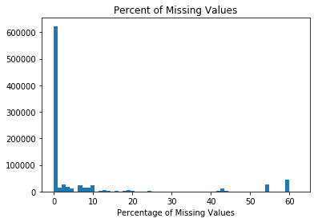

```python
# Histogram of the percentage of data missing in the rows.
plt.hist(percentage_null_row['percentage_null'], bins=60)
plt.title('Percent of Missing Values')
plt.xlabel('Percentage of Missing Values')
plt.show()
```

```python
# Write code to divide the data into two subsets based on the number of missing
# values in each row.

azdias_ls_5 = azdias[azdias.isnull().sum(axis=1) <= 5]
azdias_mt_5 = azdias[azdias.isnull().sum(axis=1) > 5]
```

```python
azdias_ls_5.head()
```

|  | ALTERSKATEGORIE_GROB | ANREDE_KZ | CJT_GESAMTTYP | FINANZ_MINIMALIST | FINANZ_SPARER | FINANZ_VORSORGER | FINANZ_ANLEGER | FINANZ_UNAUFFAELLIGER | FINANZ_HAUSBAUER | FINANZTYP | ... | PLZ8_ANTG1 | PLZ8_ANTG2 | PLZ8_ANTG3 | PLZ8_ANTG4 | PLZ8_BAUMAX | PLZ8_HHZ | PLZ8_GBZ | ARBEIT | ORTSGR_KLS9 | RELAT_AB |
| --- | --- | --- | --- | --- | --- | --- | --- | --- | --- | --- | --- | --- | --- | --- | --- | --- | --- | --- | --- | --- | --- |
| 1 | 1.0 | 2.0 | 5.0 | 1.0 | 5.0 | 2.0 | 5.0 | 4.0 | 5.0 | 1.0 | ... | 2.0 | 3.0 | 2.0 | 1.0 | 1.0 | 5.0 | 4.0 | 3.0 | 5.0 | 4.0 |
| 2 | 3.0 | 2.0 | 3.0 | 1.0 | 4.0 | 1.0 | 2.0 | 3.0 | 5.0 | 1.0 | ... | 3.0 | 3.0 | 1.0 | 0.0 | 1.0 | 4.0 | 4.0 | 3.0 | 5.0 | 2.0 |
| 4 | 3.0 | 1.0 | 5.0 | 4.0 | 3.0 | 4.0 | 1.0 | 3.0 | 2.0 | 5.0 | ... | 2.0 | 4.0 | 2.0 | 1.0 | 2.0 | 3.0 | 3.0 | 4.0 | 6.0 | 5.0 |
| 5 | 1.0 | 2.0 | 2.0 | 3.0 | 1.0 | 5.0 | 2.0 | 2.0 | 5.0 | 2.0 | ... | 2.0 | 3.0 | 1.0 | 1.0 | 1.0 | 5.0 | 5.0 | 2.0 | 3.0 | 3.0 |
| 6 | 2.0 | 2.0 | 5.0 | 1.0 | 5.0 | 1.0 | 5.0 | 4.0 | 3.0 | 4.0 | ... | 3.0 | 3.0 | 1.0 | 0.0 | 1.0 | 5.0 | 5.0 | 4.0 | 6.0 | 3.0 |

5 rows × 79 columns

```python
azdias_ls_5.columns
```

```
Index(['ALTERSKATEGORIE_GROB', 'ANREDE_KZ', 'CJT_GESAMTTYP',
       'FINANZ_MINIMALIST', 'FINANZ_SPARER', 'FINANZ_VORSORGER',
       'FINANZ_ANLEGER', 'FINANZ_UNAUFFAELLIGER', 'FINANZ_HAUSBAUER',
       'FINANZTYP', 'GFK_URLAUBERTYP', 'GREEN_AVANTGARDE', 'HEALTH_TYP',
       'LP_LEBENSPHASE_FEIN', 'LP_LEBENSPHASE_GROB', 'LP_FAMILIE_FEIN',
       'LP_FAMILIE_GROB', 'LP_STATUS_FEIN', 'LP_STATUS_GROB',
       'NATIONALITAET_KZ', 'PRAEGENDE_JUGENDJAHRE', 'RETOURTYP_BK_S',
       'SEMIO_SOZ', 'SEMIO_FAM', 'SEMIO_REL', 'SEMIO_MAT', 'SEMIO_VERT',
       'SEMIO_LUST', 'SEMIO_ERL', 'SEMIO_KULT', 'SEMIO_RAT', 'SEMIO_KRIT',
       'SEMIO_DOM', 'SEMIO_KAEM', 'SEMIO_PFLICHT', 'SEMIO_TRADV',
       'SHOPPER_TYP', 'SOHO_KZ', 'VERS_TYP', 'ZABEOTYP', 'ANZ_PERSONEN',
       'ANZ_TITEL', 'HH_EINKOMMEN_SCORE', 'W_KEIT_KIND_HH', 'WOHNDAUER_2008',
       'ANZ_HAUSHALTE_AKTIV', 'ANZ_HH_TITEL', 'GEBAEUDETYP', 'KONSUMNAEHE',
       'MIN_GEBAEUDEJAHR', 'OST_WEST_KZ', 'WOHNLAGE', 'CAMEO_DEUG_2015',
       'CAMEO_DEU_2015', 'CAMEO_INTL_2015', 'KBA05_ANTG1', 'KBA05_ANTG2',
       'KBA05_ANTG3', 'KBA05_ANTG4', 'KBA05_GBZ', 'BALLRAUM', 'EWDICHTE',
       'INNENSTADT', 'GEBAEUDETYP_RASTER', 'KKK', 'MOBI_REGIO',
       'ONLINE_AFFINITAET', 'REGIOTYP', 'KBA13_ANZAHL_PKW', 'PLZ8_ANTG1',
       'PLZ8_ANTG2', 'PLZ8_ANTG3', 'PLZ8_ANTG4', 'PLZ8_BAUMAX', 'PLZ8_HHZ',
       'PLZ8_GBZ', 'ARBEIT', 'ORTSGR_KLS9', 'RELAT_AB'],
      dtype='object')
```

```python
# Compare the distribution of values for at least five columns where there are
# no or few missing values, between the two subsets.
columns_zero_null = percentage_null_column[percentage_null_column['percentage_null'] == 0]['column']
```

```python
# Number of columns with 0% data missing in columns.
len(columns_zero_null)
```

```
24
```

```python
# Randomly choosing 5 columns with 0% missing data.
randomlist = random.sample(range(0, 23), 5)
print(randomlist)
random_5_columns = [columns_zero_null.values[i] for i in randomlist]
```

```
[7, 11, 12, 4, 6]
```

```python
# Name of the random 5 columns
random_5_columns
```

```
['FINANZTYP', 'SEMIO_REL', 'SEMIO_MAT', 'FINANZ_ANLEGER', 'FINANZ_HAUSBAUER']
```

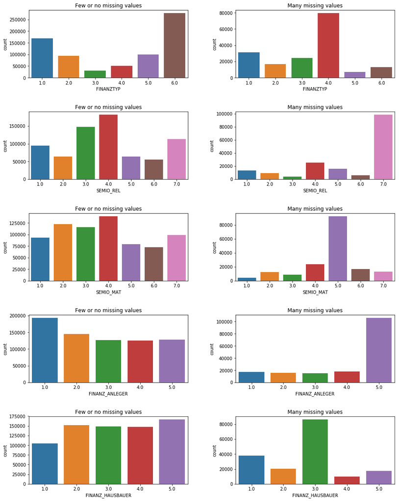

```python
# Compare the distribution of values for at least five columns where there are
# no or few missing values, between the two subsets.


figure, axs = plt.subplots(nrows=len(random_5_columns), ncols=2, figsize = (15,20))
figure.subplots_adjust(hspace = .5, wspace=.3)
for i in range(len(random_5_columns)):
    sns.countplot(azdias_ls_5[random_5_columns[i]], ax=axs[i][0])
    axs[i][0].set_title('Few or no missing values')
    sns.countplot(azdias_mt_5[random_5_columns[i]], ax=axs[i][1])
    axs[i][1].set_title('Many missing values')
```

### Step 1.2: Select and Re-Encode Features

Checking for missing data isn't the only way in which you can prepare a dataset for analysis. Since the unsupervised learning techniques to be used will only work on data that is encoded numerically, you need to make a few encoding changes or additional assumptions to be able to make progress. In addition, while almost all of the values in the dataset are encoded using numbers, not all of them represent numeric values. Check the third column of the feature summary (`feat_info`) for a summary of types of measurement.

- For numeric and interval data, these features can be kept without changes.
- Most of the variables in the dataset are ordinal in nature. While ordinal values may technically be non-linear in spacing, make the simplifying assumption that the ordinal variables can be treated as being interval in nature (that is, kept without any changes).
- Special handling may be necessary for the remaining two variable types: categorical, and 'mixed'.

In the first two parts of this sub-step, you will perform an investigation of the categorical and mixed-type features and make a decision on each of them, whether you will keep, drop, or re-encode each. Then, in the last part, you will create a new data frame with only the selected and engineered columns.

Data wrangling is often the trickiest part of the data analysis process, and there's a lot of it to be done here. But stick with it: once you're done with this step, you'll be ready to get to the machine learning parts of the project!

```python
# Removing all the columns we dropped that had > 20% missing data per column.
feat_info_remove_columns = feat_info.copy()
for column in drop_columns:
    feat_info_remove_columns = feat_info_remove_columns[feat_info_remove_columns['attribute'] != column]
```

```python
# features left in the dataset.
feat_info_remove_columns.groupby('type')['attribute'].count()
```

```
type
categorical    18
mixed           6
numeric         6
ordinal        49
Name: attribute, dtype: int64
```

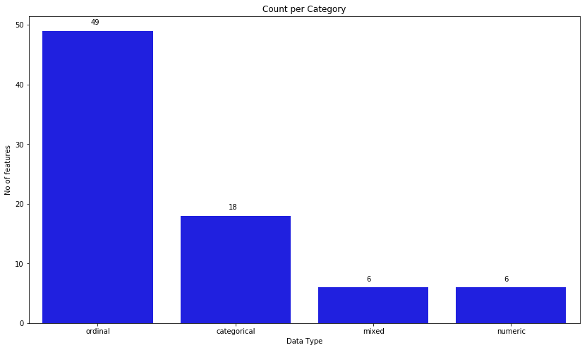

```python
# Bar chart of the visual distribution of categories left in the dataset.
fig, ax1 = plt.subplots(figsize=(14,8))
ax1.set_title('Count per Category')
sns.countplot(data=feat_info_remove_columns,
              x='type',
              color='b',
              ax=ax1)
ax1.set_ylabel('No of features')
ax1.set_xlabel('Data Type')
for p in ax1.patches:
    ax1.annotate('{:.0f}'.format(p.get_height()), (p.get_x()+0.35, p.get_height()+1))
```

#### Step 1.2.1: Re-Encode Categorical Features

For categorical data, you would ordinarily need to encode the levels as dummy variables. Depending on the number of categories, perform one of the following:

- For binary (two-level) categoricals that take numeric values, you can keep them without needing to do anything.
- There is one binary variable that takes on non-numeric values. For this one, you need to re-encode the values as numbers or create a dummy variable.
- For multi-level categoricals (three or more values), you can choose to encode the values using multiple dummy variables (e.g. via [OneHotEncoder](http://scikit-learn.org/stable/modules/generated/sklearn.preprocessing.OneHotEncoder.html)), or (to keep things straightforward) just drop them from the analysis. As always, document your choices in the Discussion section.

```python
# Creating a list of categorical features.
categorical_columns = feat_info_remove_columns[feat_info_remove_columns['type'] == 'categorical']['attribute'].values
```

```python
# Creating a categorical dataframe from azdias_ls_5

categorical = azdias_ls_5[categorical_columns]
```

```python
categorical.head()
```

|  | ANREDE_KZ | CJT_GESAMTTYP | FINANZTYP | GFK_URLAUBERTYP | GREEN_AVANTGARDE | LP_FAMILIE_FEIN | LP_FAMILIE_GROB | LP_STATUS_FEIN | LP_STATUS_GROB | NATIONALITAET_KZ | SHOPPER_TYP | SOHO_KZ | VERS_TYP | ZABEOTYP | GEBAEUDETYP | OST_WEST_KZ | CAMEO_DEUG_2015 | CAMEO_DEU_2015 |
| --- | --- | --- | --- | --- | --- | --- | --- | --- | --- | --- | --- | --- | --- | --- | --- | --- | --- | --- |
| 1 | 2.0 | 5.0 | 1.0 | 10.0 | 0 | 5.0 | 3.0 | 2.0 | 1.0 | 1.0 | 3.0 | 1.0 | 2.0 | 5.0 | 8.0 | W | 8 | 8A |
| 2 | 2.0 | 3.0 | 1.0 | 10.0 | 1 | 1.0 | 1.0 | 3.0 | 2.0 | 1.0 | 2.0 | 0.0 | 1.0 | 5.0 | 1.0 | W | 4 | 4C |
| 4 | 1.0 | 5.0 | 5.0 | 5.0 | 0 | 10.0 | 5.0 | 3.0 | 2.0 | 1.0 | 2.0 | 0.0 | 2.0 | 4.0 | 1.0 | W | 6 | 6B |
| 5 | 2.0 | 2.0 | 2.0 | 1.0 | 0 | 1.0 | 1.0 | 4.0 | 2.0 | 1.0 | 0.0 | 0.0 | 2.0 | 4.0 | 1.0 | W | 8 | 8C |
| 6 | 2.0 | 5.0 | 4.0 | 12.0 | 0 | 1.0 | 1.0 | 2.0 | 1.0 | 1.0 | 1.0 | 0.0 | 1.0 | 4.0 | 1.0 | W | 4 | 4A |

```python
# Re-encode categorical variable(s) to be kept in the analysis.

azdias_ls_5['OST_WEST_KZ'] =azdias_ls_5['OST_WEST_KZ'].map({'W': 0, 'O':1})
```

```python
azdias_ls_5['OST_WEST_KZ'] = azdias_ls_5['OST_WEST_KZ'].astype(int)
```

```python
# Distinguishing multi and binary attributes.
binary = []
multi = []
for attribute in categorical_columns:
    if len(azdias_ls_5[attribute].unique()) == 2:
        binary.append(attribute)
    elif len(azdias_ls_5[attribute].unique()) >2:
        multi.append(attribute)
    else:
        print(attribute)
```

```python
binary
```

```
['ANREDE_KZ', 'GREEN_AVANTGARDE', 'SOHO_KZ', 'OST_WEST_KZ']
```

```python
# Creating new dataframe
azdias_clean = azdias_ls_5.copy()
```

```python
# Dropping all the multi features.
for attribute in multi:
    azdias_clean=azdias_clean.drop(attribute, axis=1)
```

```python
azdias_clean.columns
```

```
Index(['ALTERSKATEGORIE_GROB', 'ANREDE_KZ', 'FINANZ_MINIMALIST',
       'FINANZ_SPARER', 'FINANZ_VORSORGER', 'FINANZ_ANLEGER',
       'FINANZ_UNAUFFAELLIGER', 'FINANZ_HAUSBAUER', 'GREEN_AVANTGARDE',
       'HEALTH_TYP', 'LP_LEBENSPHASE_FEIN', 'LP_LEBENSPHASE_GROB',
       'PRAEGENDE_JUGENDJAHRE', 'RETOURTYP_BK_S', 'SEMIO_SOZ', 'SEMIO_FAM',
       'SEMIO_REL', 'SEMIO_MAT', 'SEMIO_VERT', 'SEMIO_LUST', 'SEMIO_ERL',
       'SEMIO_KULT', 'SEMIO_RAT', 'SEMIO_KRIT', 'SEMIO_DOM', 'SEMIO_KAEM',
       'SEMIO_PFLICHT', 'SEMIO_TRADV', 'SOHO_KZ', 'ANZ_PERSONEN', 'ANZ_TITEL',
       'HH_EINKOMMEN_SCORE', 'W_KEIT_KIND_HH', 'WOHNDAUER_2008',
       'ANZ_HAUSHALTE_AKTIV', 'ANZ_HH_TITEL', 'KONSUMNAEHE',
       'MIN_GEBAEUDEJAHR', 'OST_WEST_KZ', 'WOHNLAGE', 'CAMEO_INTL_2015',
       'KBA05_ANTG1', 'KBA05_ANTG2', 'KBA05_ANTG3', 'KBA05_ANTG4', 'KBA05_GBZ',
       'BALLRAUM', 'EWDICHTE', 'INNENSTADT', 'GEBAEUDETYP_RASTER', 'KKK',
       'MOBI_REGIO', 'ONLINE_AFFINITAET', 'REGIOTYP', 'KBA13_ANZAHL_PKW',
       'PLZ8_ANTG1', 'PLZ8_ANTG2', 'PLZ8_ANTG3', 'PLZ8_ANTG4', 'PLZ8_BAUMAX',
       'PLZ8_HHZ', 'PLZ8_GBZ', 'ARBEIT', 'ORTSGR_KLS9', 'RELAT_AB'],
      dtype='object')
```

#### Discussion 1.2.1: Re-Encode Categorical Features

1. In the analysis we figured out there were 18 categorical features.
2. After taking a look at categorical values, we found that OST_WEST_KZ had to be encoded into binary numerical values.
3. There were 14 columns categorical features that had more three or more values. For those features we dropped the columns to keep it straight forward.

#### Step 1.2.2: Engineer Mixed-Type Features

There are a handful of features that are marked as "mixed" in the feature summary that require special treatment in order to be included in the analysis. There are two in particular that deserve attention; the handling of the rest are up to your own choices:

- "PRAEGENDE_JUGENDJAHRE" combines information on three dimensions: generation by decade, movement (mainstream vs. avantgarde), and nation (east vs. west). While there aren't enough levels to disentangle east from west, you should create two new variables to capture the other two dimensions: an interval-type variable for decade, and a binary variable for movement.
- "CAMEO_INTL_2015" combines information on two axes: wealth and life stage. Break up the two-digit codes by their 'tens'-place and 'ones'-place digits into two new ordinal variables (which, for the purposes of this project, is equivalent to just treating them as their raw numeric values).
- If you decide to keep or engineer new features around the other mixed-type features, make sure you note your steps in the Discussion section.

Be sure to check `Data_Dictionary.md` for the details needed to finish these tasks.

```python
# Investigate "PRAEGENDE_JUGENDJAHRE" by creating a dataframe for 'mixed' features.
mixed_columns = feat_info_remove_columns[feat_info_remove_columns['type'] == 'mixed']['attribute'].values

mixed = azdias_ls_5[mixed_columns]
```

```python
mixed.head()
```

|  | LP_LEBENSPHASE_FEIN | LP_LEBENSPHASE_GROB | PRAEGENDE_JUGENDJAHRE | WOHNLAGE | CAMEO_INTL_2015 | PLZ8_BAUMAX |
| --- | --- | --- | --- | --- | --- | --- |
| 1 | 21.0 | 6.0 | 14.0 | 4.0 | 51 | 1.0 |
| 2 | 3.0 | 1.0 | 15.0 | 2.0 | 24 | 1.0 |
| 4 | 32.0 | 10.0 | 8.0 | 3.0 | 43 | 2.0 |
| 5 | 8.0 | 2.0 | 3.0 | 7.0 | 54 | 1.0 |
| 6 | 2.0 | 1.0 | 10.0 | 5.0 | 22 | 1.0 |

#### Transformation of PRAEGENDE_JUGENDJAHRE

#### Data Dictionary:

PRAEGENDE_JUGENDJAHRE: Dominating movement of person's youth (avantgarde vs. mainstream; east vs. west)

- -1: unknown
- 0: unknown
- 1: 40s - war years (Mainstream, E+W)
- 2: 40s - reconstruction years (Avantgarde, E+W)
- 3: 50s - economic miracle (Mainstream, E+W)
- 4: 50s - milk bar / Individualisation (Avantgarde, E+W)
- 5: 60s - economic miracle (Mainstream, E+W)
- 6: 60s - generation 68 / student protestors (Avantgarde, W)
- 7: 60s - opponents to the building of the Wall (Avantgarde, E)
- 8: 70s - family orientation (Mainstream, E+W)
- 9: 70s - peace movement (Avantgarde, E+W)
- 10: 80s - Generation Golf (Mainstream, W)
- 11: 80s - ecological awareness (Avantgarde, W)
- 12: 80s - FDJ / communist party youth organisation (Mainstream, E)
- 13: 80s - Swords into ploughshares (Avantgarde, E)
- 14: 90s - digital media kids (Mainstream, E+W)
- 15: 90s - ecological awareness (Avantgarde, E+W)

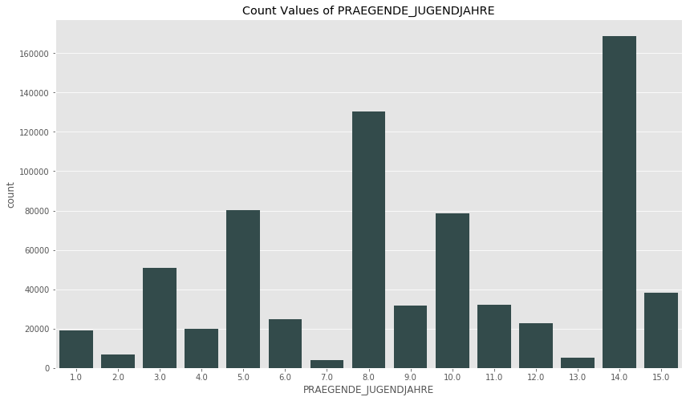

```python
# Barchart of the distribution of labels for PRAEGENDE_JUGENDJAHRE.
plt.style.use('ggplot')
fig, ax1 = plt.subplots(figsize=(14,8))
ax1.set_title('Count Values of PRAEGENDE_JUGENDJAHRE')
sns.countplot(data=mixed,
              x='PRAEGENDE_JUGENDJAHRE',
              color="darkslategray",
              ax=ax1);
```

```python
# Unique values for PRAEGENDE_JUGENDJAHRE
mixed.PRAEGENDE_JUGENDJAHRE.unique()
```

```
array([ 14.,  15.,   8.,   3.,  10.,  11.,   9.,   6.,   4.,  nan,   5.,
         2.,   1.,  12.,  13.,   7.])
```

```python
# Count of unique values for PRAEGENDE_JUGENDJAHRE
mixed.PRAEGENDE_JUGENDJAHRE.nunique()
```

```
15
```

```python
# Counts of each unique value for PRAEGENDE_JUGENDJAHRE
mixed.PRAEGENDE_JUGENDJAHRE.value_counts()
```

```
14.0    168815
8.0     130339
5.0      80064
10.0     78492
3.0      50728
15.0     38221
11.0     31951
9.0      31607
6.0      24650
12.0     22855
4.0      19715
1.0      18924
2.0       7044
13.0      5050
7.0       3805
Name: PRAEGENDE_JUGENDJAHRE, dtype: int64
```

```python
# Number of nulls in the PRAEGENDE_JUGENDJAHRE column
mixed.PRAEGENDE_JUGENDJAHRE.isnull().sum()
```

```
7364
```

```python
# Percent of PRAEGENDE_JUGENDJAHRE that is null
print(str(round((mixed.PRAEGENDE_JUGENDJAHRE.isnull().sum()/len(mixed))*100)) + ' %')
```

```
1.0 %
```

##### Data Dictionary

New Variables Data encoding:

ENG_DECADE:

Person’s decade of youth.

- 1: 40s
- 2: 50s
- 3: 60s
- 4: 70s
- 5: 80s
- 6: 90s

ENG_MOVEMENT:

Person’s movement alignment.

- 1: Mainstream
- 2: Avantgarde

```python
# Data Dictionaries for both decade and movement to map new values.
decade_dict = {1: 1, 2: 1, 3: 2, 4: 2, 5: 3, 6: 3, 7:  3,
               8: 4, 9: 4, 10: 5, 11: 5, 12: 5, 13: 5,
               14: 6, 15: 6
              }
movement_dict = {1: 1, 3: 1, 5: 1, 8: 1, 10: 1, 12: 1, 14: 1,
                2: 2, 4: 2, 6: 2, 7: 2, 9: 2, 11: 2, 13: 2, 15: 2
                }

# It appears that map is approximately 10x faster than replace.
# Ref: https://stackoverflow.com/questions/20250771/remap-values-in-pandas-column-with-a-dict
azdias_clean['DECADE'] = azdias_clean['PRAEGENDE_JUGENDJAHRE'].map(decade_dict)
azdias_clean['MOVEMENT'] = azdias_clean['PRAEGENDE_JUGENDJAHRE'].map(movement_dict)
```

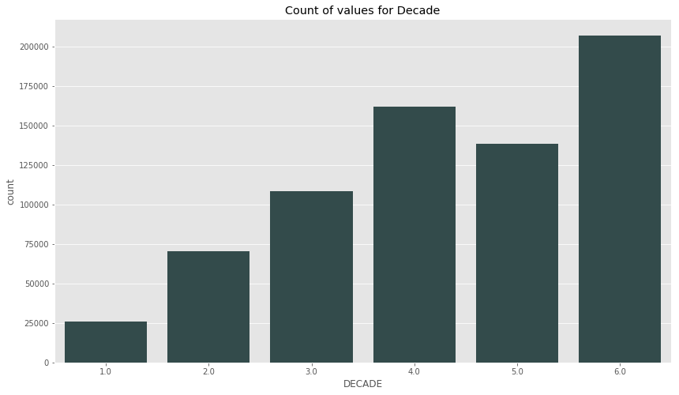

```python
# Distribution of decade
fig, ax1 = plt.subplots(figsize=(14,8))
ax1.set_title('Count of values for Decade')
sns.countplot(data=azdias_clean,
              x='DECADE',
              color="darkslategray",
              ax=ax1);
```

```python
# Count of decade per unique values.
azdias_clean.DECADE.value_counts()
```

```
6.0    207036
4.0    161946
5.0    138348
3.0    108519
2.0     70443
1.0     25968
Name: DECADE, dtype: int64
```

```python
# Sanity check that we have the same amount of nulls.
azdias_clean.DECADE.isnull().sum()
```

```
7364
```

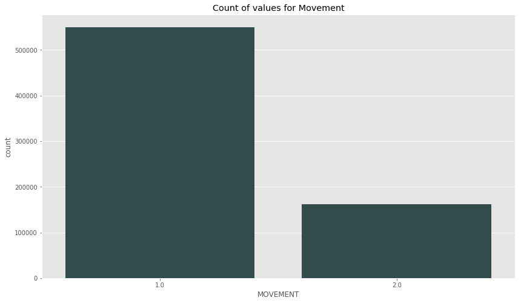

```python
# Distribution of movement.
fig, ax1 = plt.subplots(figsize=(14,8))
ax1.set_title('Count of values for Movement')
sns.countplot(data=azdias_clean,
              x='MOVEMENT',
              color="darkslategray",
              ax=ax1);
```

```python
# Count per unique values of movement.
azdias_clean.MOVEMENT.value_counts()
```

```
1.0    550217
2.0    162043
Name: MOVEMENT, dtype: int64
```

```python
# Sanity check that it has the same amount of null values.
azdias_clean.MOVEMENT.isnull().sum()
```

```
7364
```

#### Transformation of CAMEO_INTL_2015:

#### Data Dictionary

CAMEO_INTL_2015: Wealth / Life Stage Typology, mapped to international code

- -1: unknown
- 11: Wealthy Households - Pre-Family Couples & Singles
- 12: Wealthy Households - Young Couples With Children
- 13: Wealthy Households - Families With School Age Children
- 14: Wealthy Households - Older Families & Mature Couples
- 15: Wealthy Households - Elders In Retirement
- 21: Prosperous Households - Pre-Family Couples & Singles
- 22: Prosperous Households - Young Couples With Children
- 23: Prosperous Households - Families With School Age Children
- 24: Prosperous Households - Older Families & Mature Couples
- 25: Prosperous Households - Elders In Retirement
- 31: Comfortable Households - Pre-Family Couples & Singles
- 32: Comfortable Households - Young Couples With Children
- 33: Comfortable Households - Families With School Age Children
- 34: Comfortable Households - Older Families & Mature Couples
- 35: Comfortable Households - Elders In Retirement
- 41: Less Affluent Households - Pre-Family Couples & Singles
- 42: Less Affluent Households - Young Couples With Children
- 43: Less Affluent Households - Families With School Age Children
- 44: Less Affluent Households - Older Families & Mature Couples
- 45: Less Affluent Households - Elders In Retirement
- 51: Poorer Households - Pre-Family Couples & Singles
- 52: Poorer Households - Young Couples With Children
- 53: Poorer Households - Families With School Age Children
- 54: Poorer Households - Older Families & Mature Couples
- 55: Poorer Households - Elders In Retirement
- XX: unknown

```python
# value counts of CAMEO_INTL_2015.
mixed.CAMEO_INTL_2015.value_counts()
```

```
51    124571
41     84709
24     81970
14     56623
43     52027
54     42522
25     36138
22     29027
45     24492
13     23488
55     22016
23     19147
52     19044
34     16913
15     15743
31     15498
44     13604
12     11439
35      9558
32      9344
33      8694
Name: CAMEO_INTL_2015, dtype: int64
```

```python
# Null values for CAMEO_INTL_2015
mixed.CAMEO_INTL_2015.isnull().sum()
```

```
3057
```

```python
print(str(round((mixed.CAMEO_INTL_2015.isnull().sum()/len(mixed))*100)) + ' %')
```

```
0.0 %
```

New Variables Data encoding:

ENG_WEALTH:

Household's wealth

- 1: Wealthy Households
- 2: Prosperous Households
- 3: Comfortable Households
- 4: Less Affluent Households
- 5: Poorer Households

ENG_LIFE_STAGE:

Person's Life Stage

- 1: Pre-Family Couples & Singles
- 2: Young Couples With Children
- 3: Families With School Age Children
- 4: Older Families & Mature Couples
- 5: Elders In Retirement

```python
def seperate_codes(x):
    '''
    Function takes a value and returns the digit 1 and digit 2.
    Input: Two digit integer.
    Output: List containing two integers.

    '''
    if not pd.isna(x):
        return [int(str(x)[0]), int(str(x)[1])]
    else:
        return [np.nan, np.nan]
```

```python
# creating temp column to recieve list from function seperate_codes
azdias_clean['temp'] = azdias_clean['CAMEO_INTL_2015'].apply(seperate_codes)
```

```python
# Reassigning values from the 'temp' column and then deleting the 'temp' column.
azdias_clean['WEALTH'] = azdias_clean['temp'].apply(lambda x: x[0])
azdias_clean['LIFE_STAGE'] = azdias_clean['temp'].apply(lambda x: x[1])
azdias_clean.drop('temp', axis =1, inplace = True)
```

```python
azdias_clean['CAMEO_INTL_2015'].unique()
```

```
array(['51', '24', '43', '54', '22', '14', '13', '15', '34', '55', '33',
       '12', '41', '25', nan, '23', '31', '52', '35', '45', '44', '32'], dtype=object)
```

```python
azdias_clean.WEALTH.value_counts()
```

```
5.0    208153
4.0    174832
2.0    166282
1.0    107293
3.0     60007
Name: WEALTH, dtype: int64
```

```python
azdias_clean.WEALTH.isnull().sum()
```

```
3057
```

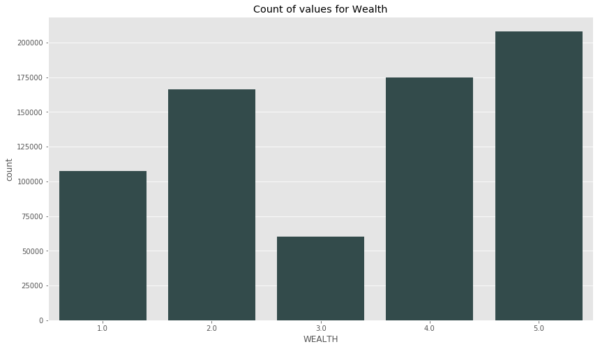

```python
# Count of 'Wealth Values'
fig, ax1 = plt.subplots(figsize=(14,8))
ax1.set_title('Count of values for Wealth')
sns.countplot(data=azdias_clean,
              x='WEALTH',
              color="darkslategray",
              ax=ax1);
```

```python
azdias_clean.LIFE_STAGE.value_counts()
```

```
1.0    224778
4.0    211632
5.0    107947
3.0    103356
2.0     68854
Name: LIFE_STAGE, dtype: int64
```

```python
azdias_clean.LIFE_STAGE.isnull().sum()
```

```
3057
```

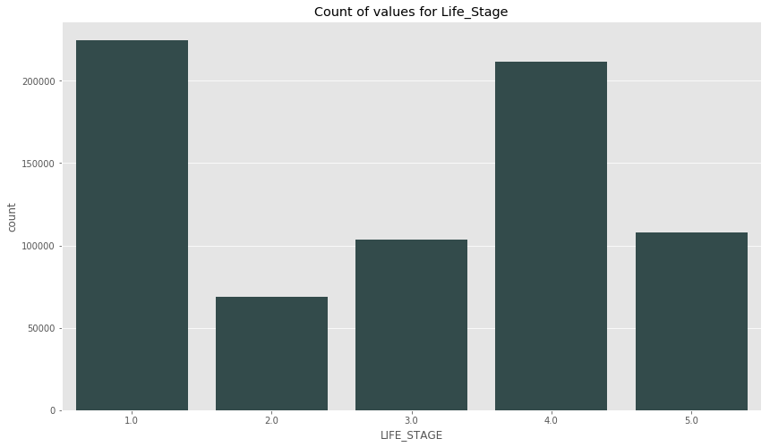

```python
fig, ax1 = plt.subplots(figsize=(14,8))
ax1.set_title('Count of values for Life_Stage')
sns.countplot(data=azdias_clean,
              x='LIFE_STAGE',
              color="darkslategray",
              ax=ax1);
```

#### Discussion 1.2.2: Engineer Mixed-Type Features

```python
# Creating new dataframe from azdias_clean.
df = azdias_clean.copy()
```

```python
# Name of df colums
df.columns
```

```
Index(['ALTERSKATEGORIE_GROB', 'ANREDE_KZ', 'FINANZ_MINIMALIST',
       'FINANZ_SPARER', 'FINANZ_VORSORGER', 'FINANZ_ANLEGER',
       'FINANZ_UNAUFFAELLIGER', 'FINANZ_HAUSBAUER', 'GREEN_AVANTGARDE',
       'HEALTH_TYP', 'LP_LEBENSPHASE_FEIN', 'LP_LEBENSPHASE_GROB',
       'PRAEGENDE_JUGENDJAHRE', 'RETOURTYP_BK_S', 'SEMIO_SOZ', 'SEMIO_FAM',
       'SEMIO_REL', 'SEMIO_MAT', 'SEMIO_VERT', 'SEMIO_LUST', 'SEMIO_ERL',
       'SEMIO_KULT', 'SEMIO_RAT', 'SEMIO_KRIT', 'SEMIO_DOM', 'SEMIO_KAEM',
       'SEMIO_PFLICHT', 'SEMIO_TRADV', 'SOHO_KZ', 'ANZ_PERSONEN', 'ANZ_TITEL',
       'HH_EINKOMMEN_SCORE', 'W_KEIT_KIND_HH', 'WOHNDAUER_2008',
       'ANZ_HAUSHALTE_AKTIV', 'ANZ_HH_TITEL', 'KONSUMNAEHE',
       'MIN_GEBAEUDEJAHR', 'OST_WEST_KZ', 'WOHNLAGE', 'CAMEO_INTL_2015',
       'KBA05_ANTG1', 'KBA05_ANTG2', 'KBA05_ANTG3', 'KBA05_ANTG4', 'KBA05_GBZ',
       'BALLRAUM', 'EWDICHTE', 'INNENSTADT', 'GEBAEUDETYP_RASTER', 'KKK',
       'MOBI_REGIO', 'ONLINE_AFFINITAET', 'REGIOTYP', 'KBA13_ANZAHL_PKW',
       'PLZ8_ANTG1', 'PLZ8_ANTG2', 'PLZ8_ANTG3', 'PLZ8_ANTG4', 'PLZ8_BAUMAX',
       'PLZ8_HHZ', 'PLZ8_GBZ', 'ARBEIT', 'ORTSGR_KLS9', 'RELAT_AB', 'DECADE',
       'MOVEMENT', 'WEALTH', 'LIFE_STAGE'],
      dtype='object')
```

```python
# Name of mixed columns
mixed.columns
```

```
Index(['LP_LEBENSPHASE_FEIN', 'LP_LEBENSPHASE_GROB', 'PRAEGENDE_JUGENDJAHRE',
       'WOHNLAGE', 'CAMEO_INTL_2015', 'PLZ8_BAUMAX'],
      dtype='object')
```

```python
# Dropping all the mixed columns.
df.drop(mixed.columns, axis = 1, inplace = True)
```

```python
# Print number of rows in df.
print(len(df))
```

```
719624
```

#### Step 1.2.3: Complete Feature Selection

In order to finish this step up, you need to make sure that your data frame now only has the columns that you want to keep. To summarize, the dataframe should consist of the following:

- All numeric, interval, and ordinal type columns from the original dataset.
- Binary categorical features (all numerically-encoded).
- Engineered features from other multi-level categorical features and mixed features.

Make sure that for any new columns that you have engineered, that you've excluded the original columns from the final dataset. Otherwise, their values will interfere with the analysis later on the project. For example, you should not keep "PRAEGENDE_JUGENDJAHRE", since its values won't be useful for the algorithm: only the values derived from it in the engineered features you created should be retained. As a reminder, your data should only be from **the subset with few or no missing values**.

### Summary

The data set contained 6 mixed variables. Out of the 6 attributes 2 were re-encoded while 4 columns were dropped:

- 'LP_LEBENSPHASE_FEIN' - According to data dictionary. Other variables have this information
- 'LP_LEBENSPHASE_GROB' - According to data dictionary. Other variables have this information
- 'WOHNLAGE' - Dropped to keep the study straight forward.
- 'PLZ8_BAUMAX' - Dropped to keep the study straight forward.

For the 2 mixed variables columns we re-encoded:

PRAEGENDE_JUGENDJAHRE indicated the dominating movement of the person's youth and decade. This created the:

- DECADE - Decade of person's youth (40s, 50s etc).
- MOVEMENT - Person's movement alignment (Mainstream, Avantgarde).

CAMEO_INTL_2015 indicating the person's wealth and life stage typology.

- WEALTH (Wealthy Households, Comfortable Households etc).
- LIFE_STAGE ( Pre-Family Couples & Singles, Young Couples with Children etc).

```python
# Sanity check that all the columns are now numeric.
from pandas.api.types import is_numeric_dtype

for i in df.columns:
    if not is_numeric_dtype(df[i]):
        print (i)
```

### Step 1.3: Create a Cleaning Function

Even though you've finished cleaning up the general population demographics data, it's important to look ahead to the future and realize that you'll need to perform the same cleaning steps on the customer demographics data. In this substep, complete the function below to execute the main feature selection, encoding, and re-engineering steps you performed above. Then, when it comes to looking at the customer data in Step 3, you can just run this function on that DataFrame to get the trimmed dataset in a single step.

```python
def replace_nan(df, feat_info):
    '''
    Function replace_nan replaces all the null values in df with feat_info 'missing_or_unknown' column values.
    Input: Two pandas dataframes.
    Output: Two dataframes.

    '''
    for attribute, missing_or_unknown in zip(feat_info['attribute'], feat_info['missing_or_unknown']):
        if missing_or_unknown[0] != '':
            for val in missing_or_unknown:
                if val.isnumeric() or val.lstrip('-').isnumeric():
                    df.loc[df[attribute] == int(val), attribute] = np.nan
                else:
                    df.loc[df[attribute] == val, attribute] = np.nan
    return df

def drop_column_nan(df, feat_info):
    '''
    Function: Removes drop columns listed in the drop_columns local list in
    both dataframes and returns dataframes.
    Input: Two dataframes.
    Output: Two dataframes

    '''
    drop_columns = ['AGER_TYP', 'GEBURTSJAHR', 'TITEL_KZ', 'ALTER_HH', 'KK_KUNDENTYP',
       'KBA05_BAUMAX']
    df.drop(columns = drop_columns, axis =1, inplace = True)
    feat_info_remove_columns = feat_info.copy()
    for column in drop_columns:
        feat_info_remove_columns = feat_info_remove_columns[feat_info_remove_columns['attribute'] != column]

    return df, feat_info_remove_columns

def drop_rows_nan(df):
    '''
    Function: Aggregates nulls by columns and creates two dataframes.
    One has less than 5% missing rows and other has more than 5%. Return two dataframes.
    Input: One dataframe (complete dataset)
    Output: Two dataframes (One >=5% and the other <5%)

    '''
    percentage_null_row = df.isnull().sum(axis =1).reset_index()
    percentage_null_row.columns = ['row', 'percentage_null']
    percentage_null_row['percentage_null'] = percentage_null_row['percentage_null'].apply(lambda x: x/len(df.columns)*100)
    df_ls_5 = df[df.isnull().sum(axis=1) <= 5]
    df_gr_5 = df[df.isnull().sum(axis=1) > 5]

    return df_ls_5, df_gr_5


def recode_drop_categorial(df, feat_info_remove_columns):
    '''
    Function: Maps numerical values to the 'OST_WEST_KZ' column. It list all the categorical features
    and drops all the multi features.
    Input: 2 dataframes (df dataset, feat_info lists the features)
    Output: df



    '''

    categorical_columns = feat_info_remove_columns[feat_info_remove_columns['type'] == 'categorical']['attribute'].values
    df['OST_WEST_KZ'] = df['OST_WEST_KZ'].map({'W': 0, 'O':1})
    binary = []
    multi = []
    for attribute in categorical_columns:
        if len(df[attribute].unique()) == 2:
            binary.append(attribute)
        elif len(df[attribute].unique()) >2:
            multi.append(attribute)
        else:
            print(feature)

    for attribute in multi:
        df=df.drop(attribute, axis=1)

    return df


def record_drop_mixed(df, feat_info_remove_columns):
    '''
    Function recodes PRAEGENDE_JUGENDJAHRE and CAMEO_INTL_2015 columns. Drops the rest of the mixed columns.
    Input: df, feat_info
    Output: df

    '''
    mixed_columns = feat_info_remove_columns[feat_info_remove_columns['type'] == 'mixed']['attribute'].values
    mixed = df[mixed_columns]

    decade_dict = {1: 1, 2: 1, 3: 2, 4: 2, 5: 3, 6: 3, 7:  3,
                   8: 4, 9: 4, 10: 5, 11: 5, 12: 5, 13: 5,
                   14: 6, 15: 6
                  }
    movement_dict = {1: 1, 3: 1, 5: 1, 8: 1, 10: 1, 12: 1, 14: 1,
                    2: 2, 4: 2, 6: 2, 7: 2, 9: 2, 11: 2, 13: 2, 15: 2
                    }

    # It appears that map is approximately 10x faster than replace.
    # Ref: https://stackoverflow.com/questions/20250771/remap-values-in-pandas-column-with-a-dict
    df['DECADE'] = df['PRAEGENDE_JUGENDJAHRE'].map(decade_dict)
    df['MOVEMENT'] = df['PRAEGENDE_JUGENDJAHRE'].map(movement_dict)



    df['temp'] = df['CAMEO_INTL_2015'].apply(seperate_codes)
    df['WEALTH'] = df['temp'].apply(lambda x: x[0])
    df['LIFE_STAGE'] = df['temp'].apply(lambda x: x[1])
    df.drop('temp', axis =1, inplace = True)
    df.drop(mixed.columns, axis = 1, inplace = True)

    return df






def seperate_codes(x):
    '''
        Function takes a value and returns the digit 1 and digit 2.
        INPUT: Two digit integer.
        OUTPUT: List containing two integers.

    '''
    if not pd.isna(x):
        return [int(str(x)[0]), int(str(x)[1])]
    else:
        return [np.nan, np.nan]
```

```python
def clean_data(df):
    """
    Perform feature trimming, re-encoding, and engineering for demographics
    data

    INPUT: Demographics DataFrame
    OUTPUT: Trimmed and cleaned demographics DataFrame with >= 5% of missing row data
    and df_nan with <5% missing row data.
    """

    # Put in code here to execute all main cleaning steps:
    # convert missing value codes into NaNs, ...


    # remove selected columns and rows, ...


    # select, re-encode, and engineer column values.


    # Reads feat_info
    feat_info =pd.read_csv('AZDIAS_Feature_Summary.csv', sep = ';')

    # Replaces 'missing_or_unknown' from a string to a list
    feat_info['missing_or_unknown'] = feat_info['missing_or_unknown'].apply(lambda x: x.strip('[]').\
                                                    split(','))

    # Convert missing value codes into NAN.
    df = replace_nan(df, feat_info)

    # Drops columns
    df, feat_info = drop_column_nan(df, feat_info)

    #Determines which rows have more and less than 5% missing data and
    #returns two dataframes seperating the data.
    df, df_nan =drop_rows_nan(df)

    #Recodes categorical data and drops multi categorical data
    df = recode_drop_categorial(df, feat_info)

    #Recodes PRAEGENDE_JUGENDJAHRE and CAMEO_INTL_2015 and drops the remaining mixed columns
    df = record_drop_mixed(df, feat_info)

    return df, df_nan
```

```python
# Load in the general demographics data.
azdias_2 = pd.read_csv('Udacity_AZDIAS_Subset.csv' ,sep= ';')

# Load in the feature summary file.
feat_info =pd.read_csv('AZDIAS_Feature_Summary.csv', sep = ';')

feat_info['missing_or_unknown'] = feat_info['missing_or_unknown'].apply(lambda x: x.strip('[]').\
                                                    split(','))
```

```python
df, df_nan = clean_data(azdias_2)
```

```python
# Sanity check, same row count as before
print(len(df))
```

```
719624
```

## Step 2: Feature Transformation

### Step 2.1: Apply Feature Scaling

Before we apply dimensionality reduction techniques to the data, we need to perform feature scaling so that the principal component vectors are not influenced by the natural differences in scale for features. Starting from this part of the project, you'll want to keep an eye on the [API reference page for sklearn](http://scikit-learn.org/stable/modules/classes.html) to help you navigate to all of the classes and functions that you'll need. In this substep, you'll need to check the following:

- sklearn requires that data not have missing values in order for its estimators to work properly. So, before applying the scaler to your data, make sure that you've cleaned the DataFrame of the remaining missing values. This can be as simple as just removing all data points with missing data, or applying an [Imputer](http://scikit-learn.org/stable/modules/generated/sklearn.preprocessing.Imputer.html) to replace all missing values. You might also try a more complicated procedure where you temporarily remove missing values in order to compute the scaling parameters before re-introducing those missing values and applying imputation. Think about how much missing data you have and what possible effects each approach might have on your analysis, and justify your decision in the discussion section below.
- For the actual scaling function, a [StandardScaler](http://scikit-learn.org/stable/modules/generated/sklearn.preprocessing.StandardScaler.html) instance is suggested, scaling each feature to mean 0 and standard deviation 1.
- For these classes, you can make use of the `.fit_transform()` method to both fit a procedure to the data as well as apply the transformation to the data at the same time. Don't forget to keep the fit sklearn objects handy, since you'll be applying them to the customer demographics data towards the end of the project.

```python
#Nans per column (feature)
(df.isnull().mean(axis=0) * 100).sort_values(ascending=False)[:18]
```

```
W_KEIT_KIND_HH          5.528165
REGIOTYP                5.383645
KKK                     5.383645
HEALTH_TYP              2.058019
MOVEMENT                1.023312
DECADE                  1.023312
RELAT_AB                0.501234
ARBEIT                  0.501234
ORTSGR_KLS9             0.490673
LIFE_STAGE              0.424805
WEALTH                  0.424805
ANZ_HAUSHALTE_AKTIV     0.367553
ALTERSKATEGORIE_GROB    0.212750
KBA13_ANZAHL_PKW        0.089213
ANZ_HH_TITEL            0.083794
INNENSTADT              0.061421
EWDICHTE                0.061421
BALLRAUM                0.061421
dtype: float64
```

```python
# Percentage of nans per row
nan_perc = (df.isnull().mean(axis=1) * 100).sort_values(ascending=False)

#How many rows have nans?
nan_perc[nan_perc > 0].shape[0]
```

```
96413
```

```python
# as a percentage of rows
print('Total percentage of row that have NaNs : ',
    round(nan_perc[nan_perc > 0].shape[0]/ df.shape[0]  * 100, 2),
      '%')
```

```
Total percentage of row that have NaNs :  13.4 %
```

```python
# Create df with no nan in rows
df_no_nan = df.dropna(axis =0)

#create Scaler object
scaler = StandardScaler()

# fit scaler to df with no nans.
scaler.fit(df_no_nan)
```

```
StandardScaler(copy=True, with_mean=True, with_std=True)
```

```python
# Create Imputer object.
imp = Imputer(missing_values='NaN', strategy='mean', axis=0)
```

```python
# Transform df with nans using Imputer
X_impute = imp.fit_transform(df)
```

```python
# Transform X_impute using scaler created from df_no_nans
X_scale = scaler.transform(X_impute)
```

```python
# create df_scale dataframe.
df_scale = pd.DataFrame(X_scale, columns=df.columns)
```

```python
df_scale.describe()
```

|  | ALTERSKATEGORIE_GROB | ANREDE_KZ | FINANZ_MINIMALIST | FINANZ_SPARER | FINANZ_VORSORGER | FINANZ_ANLEGER | FINANZ_UNAUFFAELLIGER | FINANZ_HAUSBAUER | GREEN_AVANTGARDE | HEALTH_TYP | ... | PLZ8_ANTG4 | PLZ8_HHZ | PLZ8_GBZ | ARBEIT | ORTSGR_KLS9 | RELAT_AB | DECADE | MOVEMENT | WEALTH | LIFE_STAGE |
| --- | --- | --- | --- | --- | --- | --- | --- | --- | --- | --- | --- | --- | --- | --- | --- | --- | --- | --- | --- | --- | --- |
| count | 719624.000000 | 719624.000000 | 719624.000000 | 719624.000000 | 719624.000000 | 719624.000000 | 719624.000000 | 719624.000000 | 719624.000000 | 719624.000000 | ... | 719624.000000 | 719624.000000 | 719624.000000 | 719624.000000 | 719624.000000 | 719624.000000 | 719624.000000 | 719624.000000 | 719624.000000 | 719624.000000 |
| mean | 0.000719 | 0.010488 | 0.005460 | -0.005200 | 0.005082 | 0.015548 | -0.000597 | -0.003158 | -0.022299 | 0.007562 | ... | -0.014127 | -0.002164 | 0.014404 | -0.012036 | -0.027291 | -0.016299 | 0.004341 | -0.016805 | -0.022745 | -0.001751 |
| std | 1.003459 | 0.999710 | 1.000444 | 1.003354 | 0.998931 | 1.005779 | 1.002237 | 1.008953 | 0.985685 | 0.984956 | ... | 0.996481 | 1.009211 | 0.998799 | 1.001965 | 0.999100 | 1.001133 | 1.001032 | 0.984204 | 1.003863 | 0.994487 |
| min | -1.746287 | -1.022678 | -1.512226 | -1.141397 | -1.765054 | -1.221852 | -1.139026 | -1.588887 | -0.553672 | -1.591635 | ... | -0.981973 | -2.721004 | -2.111170 | -2.223015 | -1.914219 | -1.563993 | -2.280170 | -0.553672 | -1.595951 | -1.251111 |
| 25% | -0.772089 | -1.022678 | -0.777350 | -1.141397 | -1.045045 | -1.221852 | -1.139026 | -0.856544 | -0.553672 | -0.273495 | ... | -0.981973 | -0.639701 | -0.314765 | -0.201175 | -0.607437 | -0.823841 | -0.902320 | -0.553672 | -0.909992 | -1.251111 |
| 50% | 0.202108 | 0.977825 | -0.042475 | -0.460783 | 0.394972 | 0.158605 | -0.410325 | -0.124201 | -0.553672 | -0.273495 | ... | 0.384671 | -0.639701 | -0.314765 | -0.201175 | -0.171843 | -0.083688 | -0.213395 | -0.553672 | 0.461926 | 0.082843 |
| 75% | 1.176305 | 0.977825 | 0.692400 | 0.900446 | 1.114980 | 0.848833 | 1.047076 | 0.608142 | -0.553672 | 1.044646 | ... | 0.384671 | 0.400951 | 0.583438 | 0.809745 | 0.699344 | 0.656464 | 1.164455 | -0.553672 | 1.147884 | 0.749820 |
| max | 1.176305 | 0.977825 | 1.427276 | 1.581061 | 1.114980 | 1.539061 | 1.775776 | 1.340485 | 1.806125 | 1.044646 | ... | 1.751315 | 1.441603 | 1.481641 | 1.820665 | 1.570532 | 1.396616 | 1.164455 | 1.806125 | 1.147884 | 1.416797 |

8 rows × 63 columns

```python
# Percentage of null rows in df_scale for sanity check
nan_perc = (df_scale.isnull().mean(axis=1) * 100).sort_values(ascending=False)

print('Total percentage of row that have NaNs : ',
    round(nan_perc[nan_perc > 0].shape[0]/ df_scale.shape[0]  * 100, 4),
      '%')
```

```
Total percentage of row that have NaNs :  0.0 %
```

### Step 2.2: Perform Dimensionality Reduction

On your scaled data, you are now ready to apply dimensionality reduction techniques.

- Use sklearn's [PCA](http://scikit-learn.org/stable/modules/generated/sklearn.decomposition.PCA.html) class to apply principal component analysis on the data, thus finding the vectors of maximal variance in the data. To start, you should not set any parameters (so all components are computed) or set a number of components that is at least half the number of features (so there's enough features to see the general trend in variability).
- Check out the ratio of variance explained by each principal component as well as the cumulative variance explained. Try plotting the cumulative or sequential values using matplotlib's [`plot()`](https://matplotlib.org/api/_as_gen/matplotlib.pyplot.plot.html) function. Based on what you find, select a value for the number of transformed features you'll retain for the clustering part of the project.
- Once you've made a choice for the number of components to keep, make sure you re-fit a PCA instance to perform the decided-on transformation.

```python
# Fit pca with all the features
pca = PCA().fit(X_scale)
```

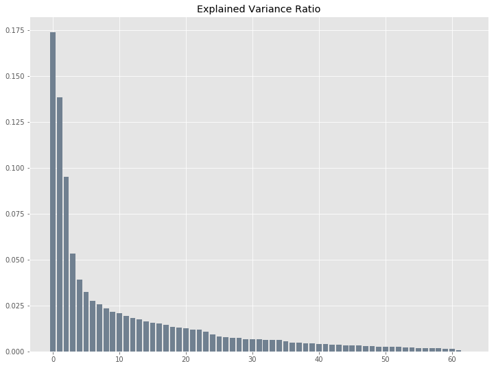

```python
# Bar chart of explain_variance_ratio
num_components=len(pca.explained_variance_ratio_)
inds = np.arange(num_components)
vals = pca.explained_variance_ratio_

fig, ax = plt.subplots(figsize=(12,9))
ax.set_title('Explained Variance Ratio')
plt.bar(inds, vals, color='slategrey');
```

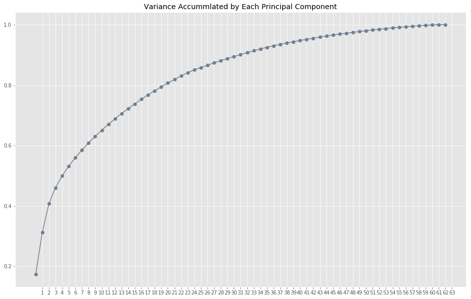

```python
# Subplot of variance accounted for by each principal component.
fig, ax = plt.subplots(figsize=(16,10))
ax.set_title('Variance Accummlated by Each Principal Component')
plt.plot(np.cumsum(pca.explained_variance_ratio_), marker='o', color='slategray')
ax.set_xticks(inds+1, minor=False);
```

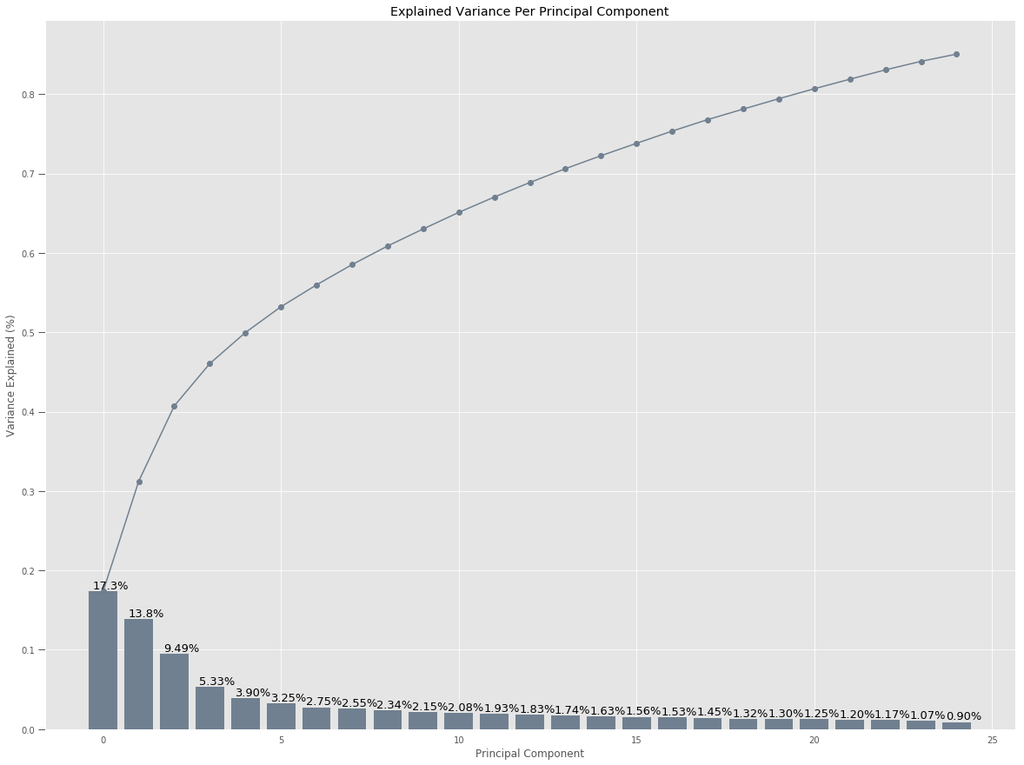

```python
def scree_plot(pca, num_bar= 25):
    '''
    Creates a scree plot associated with the principal components

    INPUT: pca - the result of instantian of PCA in scikit learn
           num_bar - numbar of bars wanted in the chart. Default is 25.

    OUTPUT:
            None
    '''
    num_components = len(pca.explained_variance_ratio_)
    ind = 0
    vals = 0
    if num_components > num_bar:
        ind = np.arange(num_bar)
        vals = pca.explained_variance_ratio_[:num_bar]
        num_components = num_bar
    else:
        ind = np.arange(num_components)
        vals = pca.explained_variance_ratio_


    plt.figure(figsize=(20, 15))
    ax = plt.subplot(111)
    cumvals = np.cumsum(vals)
    ax.bar(ind, vals, color = 'slategrey')
    ax.plot(ind, cumvals,  marker='o', color= 'slategrey')
    for i in range(num_components):
        ax.annotate(r"%s%%" % ((str(vals[i]*100)[:4])), (ind[i]+0.2, vals[i]), va="bottom", ha="center", fontsize=13)

    ax.xaxis.set_tick_params(width=0)
    ax.yaxis.set_tick_params(width=1, length=8)

    ax.set_xlabel("Principal Component")
    ax.set_ylabel("Variance Explained (%)")
    plt.title('Explained Variance Per Principal Component')


scree_plot(pca)
```

```python
# Sum of accumulated variance ratio up to the 12 component.
np.sum(pca.explained_variance_ratio_[:12])
```

```
0.67035451011555669
```

```python
# PCA for 12 components

pca = PCA(n_components = 12)
```

```python
#Fit and transform X_scale
X_pca = pca.fit_transform(X_scale)
```

```python
# create a dataframe for the components
df_comp = pd.DataFrame(X_pca)
```

```python
# Sample view of data
df_comp.head()
```

|  | 0 | 1 | 2 | 3 | 4 | 5 | 6 | 7 | 8 | 9 | 10 | 11 |
| --- | --- | --- | --- | --- | --- | --- | --- | --- | --- | --- | --- | --- |
| 0 | 3.889698 | -2.641042 | -2.966127 | -0.485881 | -2.508747 | 2.365580 | 0.566595 | -0.817926 | -0.901169 | 0.827304 | 0.098203 | -0.843297 |
| 1 | -0.923611 | 0.176789 | -3.053977 | 2.216810 | -0.897645 | -0.224189 | -1.032294 | -0.364709 | -1.194950 | -1.267799 | 0.594244 | -0.542932 |
| 2 | 0.532821 | 0.163104 | 3.193178 | 0.596869 | 1.474502 | -2.735137 | 2.187732 | -0.271674 | -1.510998 | 1.099957 | -0.613056 | 0.444970 |
| 3 | -0.749253 | -1.433072 | -1.096927 | -1.910804 | -3.260600 | -0.868491 | -0.917899 | 2.011083 | 2.697838 | 2.066116 | 0.528133 | 0.623453 |
| 4 | 0.334280 | -3.146854 | -3.545826 | -0.266619 | -1.547601 | -1.362209 | 0.117067 | 1.398667 | 1.569743 | 0.533587 | 1.501328 | 0.074360 |

```python
# Description of df_comp
df_comp.describe()
```

|  | 0 | 1 | 2 | 3 | 4 | 5 | 6 | 7 | 8 | 9 | 10 | 11 |
| --- | --- | --- | --- | --- | --- | --- | --- | --- | --- | --- | --- | --- |
| count | 7.196240e+05 | 7.196240e+05 | 7.196240e+05 | 7.196240e+05 | 7.196240e+05 | 7.196240e+05 | 7.196240e+05 | 7.196240e+05 | 7.196240e+05 | 7.196240e+05 | 7.196240e+05 | 7.196240e+05 |
| mean | 9.909351e-17 | 1.061632e-16 | 3.282053e-16 | -2.954638e-16 | -8.187359e-17 | -6.903765e-17 | -1.115543e-16 | 1.078022e-16 | 1.489760e-16 | -2.812060e-16 | -8.637605e-17 | 2.510711e-16 |
| std | 3.313420e+00 | 2.957142e+00 | 2.448921e+00 | 1.836201e+00 | 1.569962e+00 | 1.433411e+00 | 1.318446e+00 | 1.270424e+00 | 1.215764e+00 | 1.164869e+00 | 1.146604e+00 | 1.103578e+00 |
| min | -8.073835e+00 | -8.064494e+00 | -5.358823e+00 | -5.449942e+00 | -6.400150e+00 | -3.636004e+00 | -5.229641e+00 | -6.942172e+00 | -7.919400e+00 | -5.086882e+00 | -6.392855e+00 | -2.661540e+00 |
| 25% | -2.803065e+00 | -2.246368e+00 | -2.220923e+00 | -1.322759e+00 | -9.974625e-01 | -9.343537e-01 | -8.824936e-01 | -7.805116e-01 | -7.812973e-01 | -7.330563e-01 | -7.556776e-01 | -4.707772e-01 |
| 50% | -1.277304e-01 | 5.202326e-02 | -4.025301e-01 | -1.938892e-01 | 8.659589e-02 | -1.046896e-01 | 3.236391e-02 | 1.136856e-01 | -3.018785e-02 | -2.715011e-02 | 6.744232e-03 | -6.666550e-02 |
| 75% | 2.664585e+00 | 2.193392e+00 | 2.277947e+00 | 1.104265e+00 | 1.060608e+00 | 7.250383e-01 | 9.000734e-01 | 8.853320e-01 | 7.303787e-01 | 7.165957e-01 | 7.693726e-01 | 3.247123e-01 |
| max | 1.208338e+01 | 1.097840e+01 | 6.405365e+00 | 8.299653e+00 | 7.161774e+00 | 2.914527e+01 | 1.401666e+01 | 1.033450e+01 | 8.549118e+00 | 1.859612e+01 | 9.595388e+00 | 4.727229e+01 |

### Discussion 2.2: Perform Dimensionality Reduction

(Double-click this cell and replace this text with your own text, reporting your findings and decisions regarding dimensionality reduction. How many principal components / transformed features are you retaining for the next step of the analysis?)

We applied the dimensionality reduction PCA() to scale the 63 features by looking at the plot of the explain variance and the cumulative variance. We chose to keep 12 components because the cumulative variance starts decreasing it's ratio as new components are added.

### Step 2.3: Interpret Principal Components

Now that we have our transformed principal components, it's a nice idea to check out the weight of each variable on the first few components to see if they can be interpreted in some fashion.

As a reminder, each principal component is a unit vector that points in the direction of highest variance (after accounting for the variance captured by earlier principal components). The further a weight is from zero, the more the principal component is in the direction of the corresponding feature. If two features have large weights of the same sign (both positive or both negative), then increases in one tend expect to be associated with increases in the other. To contrast, features with different signs can be expected to show a negative correlation: increases in one variable should result in a decrease in the other.

- To investigate the features, you should map each weight to their corresponding feature name, then sort the features according to weight. The most interesting features for each principal component, then, will be those at the beginning and end of the sorted list. Use the data dictionary document to help you understand these most prominent features, their relationships, and what a positive or negative value on the principal component might indicate.
- You should investigate and interpret feature associations from the first three principal components in this substep. To help facilitate this, you should write a function that you can call at any time to print the sorted list of feature weights, for the *i*-th principal component. This might come in handy in the next step of the project, when you interpret the tendencies of the discovered clusters.

```python
def plot_component_pca(com_pos,com_neg, comp_num):


    # Create a bar plot visualization
    fig, ax = plt.subplots(nrows = 1, ncols = 2, figsize = (15, 8))
    fig.subplots_adjust(hspace = .5, wspace= 1 )


    com_pos = np.absolute(com_pos)
    # Plot the feature weights as a function of the components
    com_pos.plot(ax = ax[0], kind = 'barh')
    ax[0].set_xlabel('Feature Weights')
    ax[0].set_title('Positive Weights for Component {} sorted by Magnitude'.format(comp_num))

    com_neg = np.absolute(com_neg)
    # Plot the feature weights as a function of the components
    com_neg.plot(ax = ax[1], kind = 'barh')
    ax[1].set_xlabel('Absolute Value of Feature Weights')
    ax[1].set_title('Negative Weights for Component {} sorted by Magnitude'.format(comp_num))


def map_pca_weight(df, pca, comp_num):
    '''
    Create a DataFrame of the PCA results
    Includes dimension feature weights and explained variance
    Visualizes the PCA results for most positive and negative weights per component.
    INPUT: Demographics dataframe
           pca object
           Number of component to analyze
    OUTPUT: Returns top 4 most positive and negative features for the component.
    '''

    # PCA components
    weights = pd.DataFrame(np.round(pca.components_, 5), columns = df.keys())
    component_num = weights.iloc[comp_num-1,:]
    comp_pos = component_num[component_num > 0].sort_values(ascending=False)
    comp_neg = component_num[component_num < 0].sort_values(ascending=True)

    plot_component_pca(comp_pos, comp_neg, comp_num)
    return comp_pos.index[0:4], comp_neg.index[0:4]
    #plot_component_pca(comp_pos, 'Positive Weights for Component {} sorted by Magnitude'.format(comp_num), 'Feature Weights')
    #plot_component_pca(comp_neg, 'Negative Weights for Component {} sorted by Magnitude'.format(comp_num), 'Absolute Value of Feature Weights')
```

### Component 1

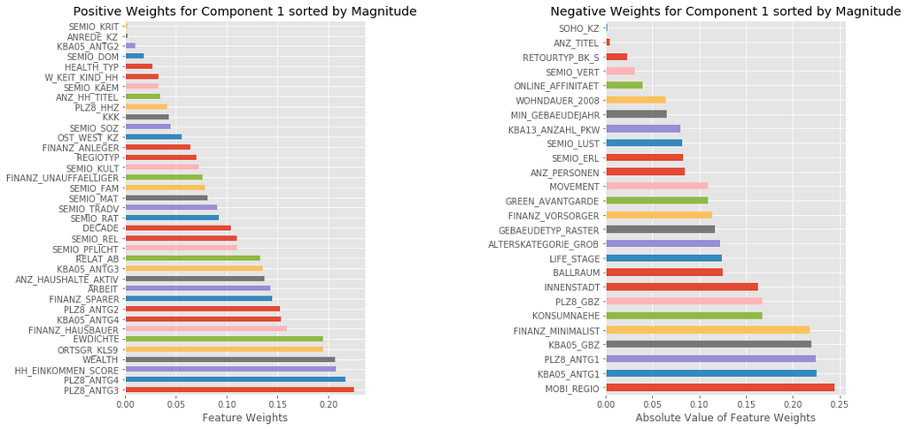

```python
# Get list of positive and negative weights for component 1.
# Graph results.
pos, neg = map_pca_weight(df_scale, pca, 1)
```

For PCA 1 we see that the four most positive features are:

- PLZ8-ANTG3 - Number of 6-10 family houses in the PLZ8 region
  - High share of 6-10 family homes since weight is dominate and high where the median is
- PLZ8-ANTG4 - Number of 10+ family houses in the PLZ8 region
  - High share of large apartment buildings
- HH_EINKOMMEN_SCORE - Estimated household net income (1 highest income, 6 low incomes)
  - Lower incomes
- WEALTH - Engineered Feature( Household Wealth). (1 highest income, 6 low incomes)
  - Poorer households.

And the four most negative features are and the assumption on their meaning relative to the 4 positive features.

- MOBI_REGIO - Movement patterns (1: very high movement, 6: No movement)
  - Low moving patterns
- KBA05_ANTG1 - Number of 1-2 family houses in the microcell (0: 1-2 homes, 4 very high share of 1-2 homes)
  - High 1-2 homes in population density.
- PLZ8_ANTG1 - Number of 1-2 family houses in the PLZ8 region
  - High 1-2 homes in population density.
- KBAO5_GBZ - Number of buildings in the microcell
  - Low number of buildings.

**The first component focuses on population density and financial power of the person.**

```python
# Create new dataframe from X_impute for analysis.
df_check = pd.DataFrame(X_impute, columns=df.columns)
```

```python
# check most positive features for component 1
df_check[pos].describe()
```

|  | PLZ8_ANTG3 | PLZ8_ANTG4 | HH_EINKOMMEN_SCORE | WEALTH |
| --- | --- | --- | --- | --- |
| count | 719624.000000 | 719624.000000 | 719624.000000 | 719624.000000 |
| mean | 1.611045 | 0.708192 | 4.474735 | 3.293441 |
| std | 0.986093 | 0.729144 | 1.537889 | 1.463445 |
| min | 0.000000 | 0.000000 | 1.000000 | 1.000000 |
| 25% | 1.000000 | 0.000000 | 4.000000 | 2.000000 |
| 50% | 2.000000 | 1.000000 | 5.000000 | 4.000000 |
| 75% | 2.000000 | 1.000000 | 6.000000 | 5.000000 |
| max | 3.000000 | 2.000000 | 6.000000 | 5.000000 |

```python
# check most negative features for component 1.
df_check[neg].describe()
```

|  | MOBI_REGIO | KBA05_ANTG1 | PLZ8_ANTG1 | KBA05_GBZ |
| --- | --- | --- | --- | --- |
| count | 719624.000000 | 719624.000000 | 719624.000000 | 719624.000000 |
| mean | 2.974937 | 1.505501 | 2.243045 | 3.163815 |
| std | 1.429187 | 1.408983 | 0.974658 | 1.328231 |
| min | 1.000000 | 0.000000 | 0.000000 | 1.000000 |
| 25% | 2.000000 | 0.000000 | 1.000000 | 2.000000 |
| 50% | 3.000000 | 1.000000 | 2.000000 | 3.000000 |
| 75% | 4.000000 | 3.000000 | 3.000000 | 4.000000 |
| max | 6.000000 | 4.000000 | 4.000000 | 5.000000 |

### Component 2

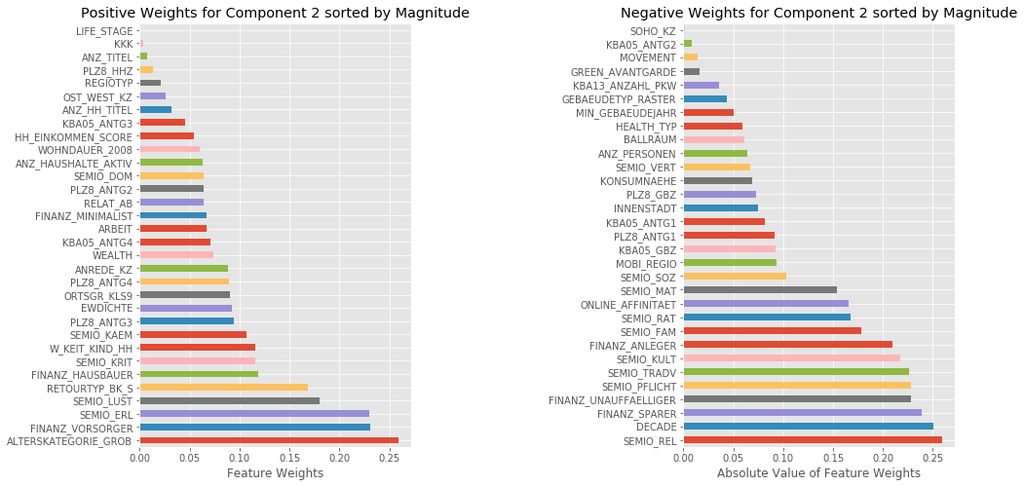

```python
# Get list of positive and negative weights for component 2.
# Graph results.

pos, neg = map_pca_weight(df_scale, pca, 2)
```

For PCA 2 we see that the four most positive features are:

- ALTERSKATEGORIE_GROB: Estimated age based on given name analysis
  - Older or uniformly distributed.
- FINANZ_VORSORGER: Financial typology
  - Lower finacial preparation
- SEMIO_ERL: Personality typology
  - Lower event oriented
- SEMIO_LUST: Personality typology
  - lower sensual-minded.

And the four most negative features are:

- SEMIO_REL: Personality typology
  - Lower relgious affinity.
- DECADE: Person’s decade of youth
  - Younger generation
- FINANZ_SPARER: Financial typology
  - lower money saver
- FINANZ_UNAUFFAELLIGER: Financial typology
  - less traditional- minded

**The second component focuses on the age, generation and personality topologies of the person (relgion, buying etc)**

```python
# Check most positive features for component 2.
df_check[pos].describe()
```

|  | ALTERSKATEGORIE_GROB | FINANZ_VORSORGER | SEMIO_ERL | SEMIO_LUST |
| --- | --- | --- | --- | --- |
| count | 719624.000000 | 719624.000000 | 719624.000000 | 719624.000000 |
| mean | 2.793277 | 3.458492 | 4.612309 | 4.344249 |
| std | 1.030037 | 1.387388 | 1.825756 | 2.097771 |
| min | 1.000000 | 1.000000 | 1.000000 | 1.000000 |
| 25% | 2.000000 | 2.000000 | 3.000000 | 2.000000 |
| 50% | 3.000000 | 4.000000 | 4.000000 | 5.000000 |
| 75% | 4.000000 | 5.000000 | 6.000000 | 6.000000 |
| max | 4.000000 | 5.000000 | 7.000000 | 7.000000 |

```python
# check most negative features for component 2
df_check[neg].describe()
```

|  | SEMIO_REL | DECADE | FINANZ_SPARER | FINANZ_UNAUFFAELLIGER |
| --- | --- | --- | --- | --- |
| count | 719624.000000 | 719624.000000 | 719624.000000 | 719624.000000 |
| mean | 3.933565 | 4.316052 | 2.669370 | 2.562273 |
| std | 1.884260 | 1.453035 | 1.474188 | 1.375376 |
| min | 1.000000 | 1.000000 | 1.000000 | 1.000000 |
| 25% | 3.000000 | 3.000000 | 1.000000 | 1.000000 |
| 50% | 4.000000 | 4.000000 | 2.000000 | 2.000000 |
| 75% | 5.000000 | 6.000000 | 4.000000 | 4.000000 |
| max | 7.000000 | 6.000000 | 5.000000 | 5.000000 |

### Component 3

```
(Index(['SEMIO_VERT', 'SEMIO_SOZ', 'SEMIO_FAM', 'SEMIO_KULT'], dtype='object'),
 Index(['ANREDE_KZ', 'SEMIO_KAEM', 'SEMIO_DOM', 'SEMIO_KRIT'], dtype='object'))
```

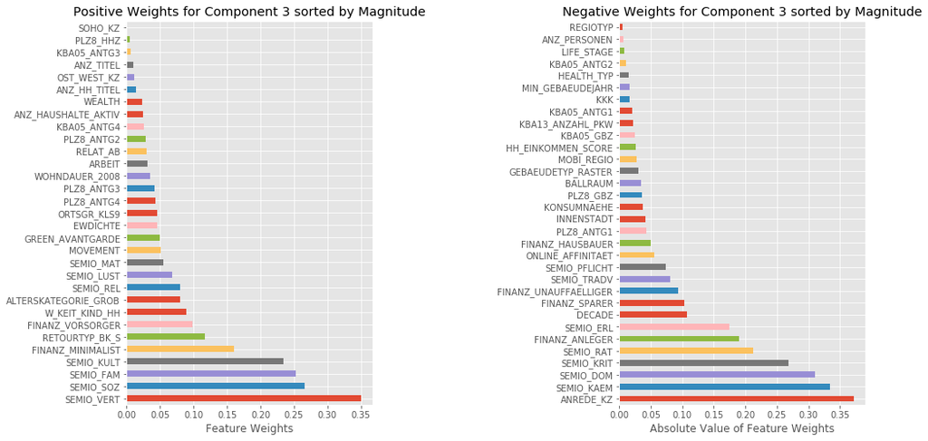

```python
# Get list of positive and negative weights for component 3.
# Graph results.

map_pca_weight(df_scale, pca, 3)
```

For PCA 3 we see that the four most positive features are:

- SEMIO_VERT: Personality Topology Dreamy (1: High, 7: Low)
  - Less dreamy
- SEMIO_SOZ: Personality Topology socially-minded (1: High, 7: Low)
  - less socially-minded
- SEMIO_FAM: Personality typology Family-minded (1: High, 7: Low)
  - less family minded
- SEMIO_KULT: Personality typology cultural-minded (1:high, 7:Low)
  - less cultural minded.

And the four most negative features are:

- ANDREDE_KZ: Gender (1 male, 2 Female)
  - Female
- SEMIO_KAEM - combative attitube (1: high, 7: low)
  - low combatitive attitude.
- SEMIO_DOM: Dominant-Minded (1: high, 7: low)
  - low dominant minded
- SEMIO_KRIT: Critical Minded (1: High, 7: Low)
  - low critical-minded

**The third component is a latent feature of gender**

## Step 3: Clustering

### Step 3.1: Apply Clustering to General Population

You've assessed and cleaned the demographics data, then scaled and transformed them. Now, it's time to see how the data clusters in the principal components space. In this substep, you will apply k-means clustering to the dataset and use the average within-cluster distances from each point to their assigned cluster's centroid to decide on a number of clusters to keep.

- Use sklearn's KMeans class to perform k-means clustering on the PCA-transformed data.
- Then, compute the average difference from each point to its assigned cluster's center. **Hint**: The KMeans object's `.score()` method might be useful here, but note that in sklearn, scores tend to be defined so that larger is better. Try applying it to a small, toy dataset, or use an internet search to help your understanding.
- Perform the above two steps for a number of different cluster counts. You can then see how the average distance decreases with an increasing number of clusters. However, each additional cluster provides a smaller net benefit. Use this fact to select a final number of clusters in which to group the data. **Warning**: because of the large size of the dataset, it can take a long time for the algorithm to resolve. The more clusters to fit, the longer the algorithm will take. You should test for cluster counts through at least 10 clusters to get the full picture, but you shouldn't need to test for a number of clusters above about 30.
- Once you've selected a final number of clusters to use, re-fit a KMeans instance to perform the clustering operation. Make sure that you also obtain the cluster assignments for the general demographics data, since you'll be using them in the final Step 3.3.

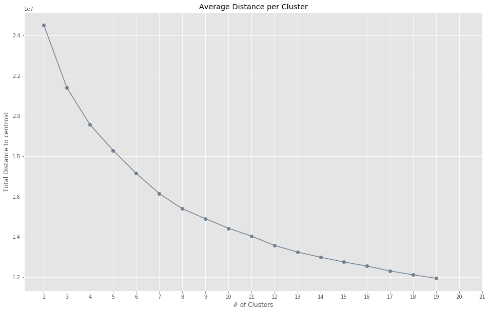

```python
# Graph the average distance to the centroid for each number of clusters
# in order to use the elbow method to determine optimal number of clusters.

scores = {}
for k in range (2, 20):
    scores[k] = np.abs(KMeans(n_clusters = k).fit(X_pca).score(X_pca))

# Plot relationship plot
fig, ax = plt.subplots(figsize=(16,10))
ax.set_title('Average Distance per Cluster')
ax = pd.Series(scores).plot(marker='o', color='slategray')
ax.set_xticks(np.arange(2, 22), minor=False);
ax.set_xlabel("# of Clusters")
ax.set_ylabel("Total Distance to centroid");
```

```python
# Re-fit the k-means model with the K= 8.
# cluster predictions for the general population demographics data.
K = 8


kmeans = KMeans(n_clusters=K,  random_state=42, n_jobs= -1).fit(X_pca)
```

### Discussion 3.1: Apply Clustering to General Population

Based on the elbow method, the total distance to the center of the centroid starts to level off around the 8 clusters. For that reason we will be using K=8 for this study.

### Step 3.2: Apply All Steps to the Customer Data

Now that you have clusters and cluster centers for the general population, it's time to see how the customer data maps on to those clusters. Take care to not confuse this for re-fitting all of the models to the customer data. Instead, you're going to use the fits from the general population to clean, transform, and cluster the customer data. In the last step of the project, you will interpret how the general population fits apply to the customer data.

- Don't forget when loading in the customers data, that it is semicolon (`;`) delimited.
- Apply the same feature wrangling, selection, and engineering steps to the customer demographics using the `clean_data()` function you created earlier. (You can assume that the customer demographics data has similar meaning behind missing data patterns as the general demographics data.)
- Use the sklearn objects from the general demographics data, and apply their transformations to the customers data. That is, you should not be using a `.fit()` or `.fit_transform()` method to re-fit the old objects, nor should you be creating new sklearn objects! Carry the data through the feature scaling, PCA, and clustering steps, obtaining cluster assignments for all of the data in the customer demographics data.

```python
# Load in the customer demographics data.
customers = pd.read_csv('Udacity_CUSTOMERS_Subset.csv', delimiter=';')
```

```python
customers.columns
```

```
Index(['AGER_TYP', 'ALTERSKATEGORIE_GROB', 'ANREDE_KZ', 'CJT_GESAMTTYP',
       'FINANZ_MINIMALIST', 'FINANZ_SPARER', 'FINANZ_VORSORGER',
       'FINANZ_ANLEGER', 'FINANZ_UNAUFFAELLIGER', 'FINANZ_HAUSBAUER',
       'FINANZTYP', 'GEBURTSJAHR', 'GFK_URLAUBERTYP', 'GREEN_AVANTGARDE',
       'HEALTH_TYP', 'LP_LEBENSPHASE_FEIN', 'LP_LEBENSPHASE_GROB',
       'LP_FAMILIE_FEIN', 'LP_FAMILIE_GROB', 'LP_STATUS_FEIN',
       'LP_STATUS_GROB', 'NATIONALITAET_KZ', 'PRAEGENDE_JUGENDJAHRE',
       'RETOURTYP_BK_S', 'SEMIO_SOZ', 'SEMIO_FAM', 'SEMIO_REL', 'SEMIO_MAT',
       'SEMIO_VERT', 'SEMIO_LUST', 'SEMIO_ERL', 'SEMIO_KULT', 'SEMIO_RAT',
       'SEMIO_KRIT', 'SEMIO_DOM', 'SEMIO_KAEM', 'SEMIO_PFLICHT', 'SEMIO_TRADV',
       'SHOPPER_TYP', 'SOHO_KZ', 'TITEL_KZ', 'VERS_TYP', 'ZABEOTYP',
       'ALTER_HH', 'ANZ_PERSONEN', 'ANZ_TITEL', 'HH_EINKOMMEN_SCORE',
       'KK_KUNDENTYP', 'W_KEIT_KIND_HH', 'WOHNDAUER_2008',
       'ANZ_HAUSHALTE_AKTIV', 'ANZ_HH_TITEL', 'GEBAEUDETYP', 'KONSUMNAEHE',
       'MIN_GEBAEUDEJAHR', 'OST_WEST_KZ', 'WOHNLAGE', 'CAMEO_DEUG_2015',
       'CAMEO_DEU_2015', 'CAMEO_INTL_2015', 'KBA05_ANTG1', 'KBA05_ANTG2',
       'KBA05_ANTG3', 'KBA05_ANTG4', 'KBA05_BAUMAX', 'KBA05_GBZ', 'BALLRAUM',
       'EWDICHTE', 'INNENSTADT', 'GEBAEUDETYP_RASTER', 'KKK', 'MOBI_REGIO',
       'ONLINE_AFFINITAET', 'REGIOTYP', 'KBA13_ANZAHL_PKW', 'PLZ8_ANTG1',
       'PLZ8_ANTG2', 'PLZ8_ANTG3', 'PLZ8_ANTG4', 'PLZ8_BAUMAX', 'PLZ8_HHZ',
       'PLZ8_GBZ', 'ARBEIT', 'ORTSGR_KLS9', 'RELAT_AB'],
      dtype='object')
```

```python
# Apply preprocessing, feature transformation, and clustering from the general
# demographics onto the customer data, obtaining cluster predictions for the
# customer demographics data.

df_cust, df_cust_high_na = clean_data(customers)
```

```python
# Sanity check number of columns for the customer dataframe.
len(df_cust.columns)
```

```
63
```

```python
# Check the df_scale number of columns.
if len(df_cust.columns) == len(df_scale.columns):
    print('Good, the prepocessing worked')
else:
    print('Something went wrong')
```

```
Good, the prepocessing worked
```

```python
# Looking at the customer dataframe shape.
df_cust.shape
```

```
(128989, 63)
```

###### Feature Transformation

```python
X_cust_imp = imp.transform(df_cust)
```

```python
X_cust_sc = scaler.transform(X_cust_imp)
```

###### Dimensionality Reduction

```python
X_cust_pca = pca.transform(X_cust_sc)
```

```python
X_cust_pca.shape
```

```
(128989, 12)
```

```python
df_cust_pca = pd.DataFrame(X_cust_pca, columns=np.arange(1, 13))
df_cust_pca.describe()
```

|  | 1 | 2 | 3 | 4 | 5 | 6 | 7 | 8 | 9 | 10 | 11 | 12 |
| --- | --- | --- | --- | --- | --- | --- | --- | --- | --- | --- | --- | --- |
| count | 128989.000000 | 128989.000000 | 128989.000000 | 128989.000000 | 128989.000000 | 128989.000000 | 128989.000000 | 128989.000000 | 128989.000000 | 128989.000000 | 128989.000000 | 128989.000000 |
| mean | -2.451719 | 1.256408 | 1.460699 | 0.928202 | -0.005341 | 0.061169 | 0.057096 | 0.031845 | -0.197346 | 0.486098 | 0.064201 | 0.094918 |
| std | 2.722411 | 2.197100 | 2.192644 | 2.012245 | 1.509328 | 1.378676 | 1.416721 | 1.142357 | 1.191269 | 1.116811 | 1.151524 | 1.943903 |
| min | -8.017192 | -7.563019 | -4.796447 | -5.304894 | -6.162798 | -3.481980 | -6.605432 | -5.773447 | -11.516519 | -5.083701 | -5.340221 | -2.648465 |
| 25% | -4.520952 | -0.111306 | -0.773017 | -0.712336 | -0.975594 | -0.710139 | -0.936583 | -0.657428 | -0.965808 | -0.272250 | -0.671585 | -0.532763 |
| 50% | -3.196109 | 1.180716 | 2.188860 | 0.972295 | 0.116988 | -0.016171 | 0.080208 | 0.098745 | -0.236406 | 0.401654 | 0.088211 | -0.159908 |
| 75% | -0.807300 | 2.677128 | 3.234127 | 2.564360 | 1.051389 | 0.659620 | 1.051364 | 0.794963 | 0.509069 | 1.183116 | 0.822495 | 0.211789 |
| max | 11.203513 | 10.955744 | 6.269208 | 9.506304 | 5.998855 | 32.916240 | 7.508357 | 9.315340 | 6.636791 | 11.996313 | 13.298870 | 68.804282 |

###### Clustering

```python
X_cust_kmeans = kmeans.predict(X_cust_pca)
```

```python
np.unique(X_cust_kmeans)
```

```
array([0, 1, 2, 3, 4, 5, 6, 7], dtype=int32)
```

### Step 3.3: Compare Customer Data to Demographics Data

At this point, you have clustered data based on demographics of the general population of Germany, and seen how the customer data for a mail-order sales company maps onto those demographic clusters. In this final substep, you will compare the two cluster distributions to see where the strongest customer base for the company is.

Consider the proportion of persons in each cluster for the general population, and the proportions for the customers. If we think the company's customer base to be universal, then the cluster assignment proportions should be fairly similar between the two. If there are only particular segments of the population that are interested in the company's products, then we should see a mismatch from one to the other. If there is a higher proportion of persons in a cluster for the customer data compared to the general population (e.g. 5% of persons are assigned to a cluster for the general population, but 15% of the customer data is closest to that cluster's centroid) then that suggests the people in that cluster to be a target audience for the company. On the other hand, the proportion of the data in a cluster being larger in the general population than the customer data (e.g. only 2% of customers closest to a population centroid that captures 6% of the data) suggests that group of persons to be outside of the target demographics.

Take a look at the following points in this step:

- Compute the proportion of data points in each cluster for the general population and the customer data. Visualizations will be useful here: both for the individual dataset proportions, but also to visualize the ratios in cluster representation between groups. Seaborn's [`countplot()`](https://seaborn.pydata.org/generated/seaborn.countplot.html) or [`barplot()`](https://seaborn.pydata.org/generated/seaborn.barplot.html) function could be handy.
  - Recall the analysis you performed in step 1.1.3 of the project, where you separated out certain data points from the dataset if they had more than a specified threshold of missing values. If you found that this group was qualitatively different from the main bulk of the data, you should treat this as an additional data cluster in this analysis. Make sure that you account for the number of data points in this subset, for both the general population and customer datasets, when making your computations!
- Which cluster or clusters are overrepresented in the customer dataset compared to the general population? Select at least one such cluster and infer what kind of people might be represented by that cluster. Use the principal component interpretations from step 2.3 or look at additional components to help you make this inference. Alternatively, you can use the `.inverse_transform()` method of the PCA and StandardScaler objects to transform centroids back to the original data space and interpret the retrieved values directly.
- Perform a similar investigation for the underrepresented clusters. Which cluster or clusters are underrepresented in the customer dataset compared to the general population, and what kinds of people are typified by these clusters?

```python
# Compare the proportion of data in each cluster for the customer data to the
# proportion of data in each cluster for the general population.

gen_pop = kmeans.labels_
gen_pop_na = np.append(gen_pop, [-1] * df_nan.shape[0])
gen_pop_na_freq = itemfreq(gen_pop_na)
gen_pop_na_prop = gen_pop_na_freq[:, 1]/ gen_pop_na_freq[:, 1].sum()
gen_pop_na_prop
gen_pop_na_freq = np.c_[gen_pop_na_freq, gen_pop_na_prop]
```

```python
cust = X_cust_kmeans
cust_na = np.append(cust, [-1] * df_cust_high_na.shape[0])
cust_na_freq = itemfreq(cust_na)
cust_na_prop = cust_na_freq[:, 1]/ cust_na_freq[:, 1].sum()
cust_na_prop
cust_na_freq = np.c_[cust_na_freq, cust_na_prop]
```

```python
# Quick look at the cust_na_freq
cust_na_freq
```

```
array([[ -1.00000000e+00,   6.26630000e+04,   3.26962411e-01],
       [  0.00000000e+00,   1.25600000e+03,   6.55354497e-03],
       [  1.00000000e+00,   6.51540000e+04,   3.39959927e-01],
       [  2.00000000e+00,   1.67410000e+04,   8.73510321e-02],
       [  3.00000000e+00,   1.29200000e+03,   6.74138543e-03],
       [  4.00000000e+00,   2.51170000e+04,   1.31055246e-01],
       [  5.00000000e+00,   3.32500000e+03,   1.73491537e-02],
       [  6.00000000e+00,   1.39020000e+04,   7.25377246e-02],
       [  7.00000000e+00,   2.20200000e+03,   1.14895749e-02]])
```

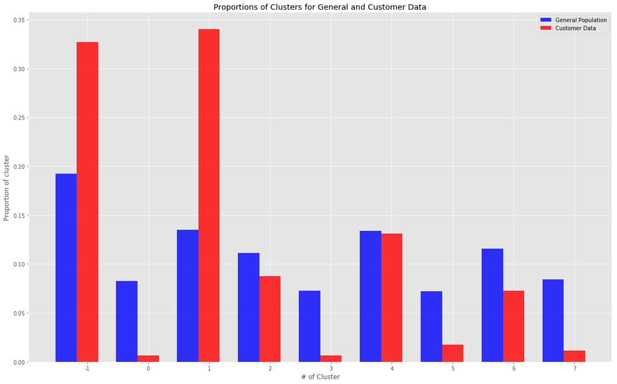

```python
# Plot side by side bar chart of proportions for the general
# population and the customer base.
fig, ax = plt.subplots(figsize=(16, 10))
index = np.append([-1], np.arange(K))
bar_width = 0.35
opacity = 0.8

gen = plt.bar(index, gen_pop_na_freq[:, 2], bar_width,
                 alpha=opacity,
                 color='b',
                 label='General Population')

cust = plt.bar(index + bar_width, cust_na_freq[:, 2], bar_width,
                 alpha=opacity,
                 color='r',
                 label='Customer Data')

plt.xlabel('# of Cluster')
plt.ylabel('Proportion of cluster')
plt.title('Proportions of Clusters for General and Customer Data')
plt.xticks(index + bar_width, index)
plt.legend()

plt.tight_layout()
sns.despine();
```

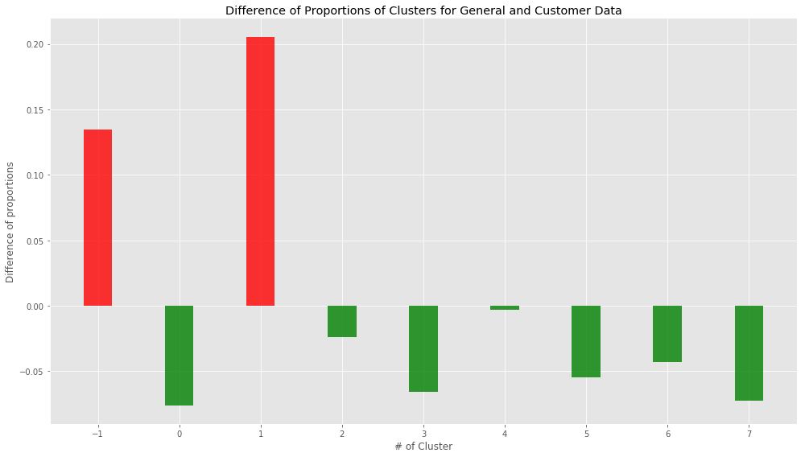

```python
#Calculate differece of proportions
K = 8
prop_diff = cust_na_freq[:, 2] - gen_pop_na_freq[:, 2]
positive= prop_diff > 0

# create plot
fig, ax = plt.subplots(figsize=(14, 8))
index = np.append([-1], np.arange(8))
bar_width = 0.35
opacity = 0.8

diff = plt.bar(index, prop_diff, bar_width,
                 alpha=opacity,
                 color=np.vectorize({True: 'r', False: 'g'}.get)(positive)
              )


plt.xlabel('# of Cluster')
plt.ylabel('Difference of proportions')
plt.title('Difference of Proportions of Clusters for General and Customer Data')
plt.xticks(index)

plt.tight_layout()
sns.despine();
```

```python
prop_diff = cust_na_freq[:, 2] - gen_pop_na_freq[:, 2]
prop_diff
```

```
array([ 0.13442094, -0.0761218 ,  0.20516957, -0.024123  , -0.06595551,
       -0.00282513, -0.05460606, -0.04317319, -0.07278582])
```

```python
df_cust_pca['cluster'] = X_cust_kmeans
```

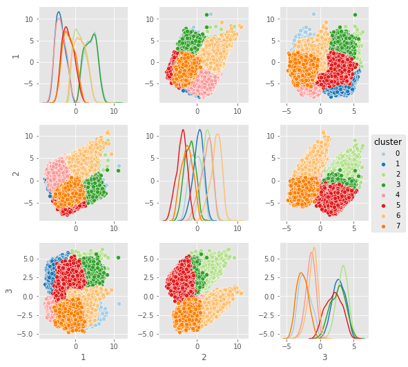

```python
g = sns.pairplot(df_cust_pca,
                 vars = [1, 2, 3],
                 diag_kind = 'kde',
                 hue="cluster",
                 palette="Paired");
```

### Discussion 3.3: Compare Customer Data to Demographics Data

#### Overrepresentation

**Cluster 1**

A cluster that shows overrepresentation in the customer data compared to the demographics data is **Cluster 1 (Dark Blue)**: Meaning that the target population of the customer data is **Young Males with higher incomes, lower moving patterns that live in less dense cities and tend to have lower religious affinities and lower traditional outlooks**. This is concluded from the pairplot chart.

- With component one, the dark blue is primarily in the negative regions, meaning lower moving patterns, less dense cities and higher income.
- For component two, we see that it is right at zero and less than zero, meaning moderate to lower religious affinity, younger and less traditionally minded.
- Finally, for component three, dark blue is greater than 0 meaning male, less dreamy and less family minded.

#### Underrepresented

**Cluster 0**

A cluster that shows the most underrepresentation in the customer data compared to the demographics data is **Cluster 0 (Baby Blue)**: Meaning that the most underrespresented population of the customer data is **Middle aged women with low incomes, living in dense cities, with semi-religious and semi-conversative ideals and who are less combatitive and less dominant.**. This is concluded from the pairplot chart.

- For component one, we see that the baby blue cluster is well above 0 in the positive area, meaning dense cities and low income.
- With component two, the baby blue cluster is equally distributed around 0, meaning semi-regligious, middle-aged and semi-convervative.
- Finally, for component three, the baby blue cluster is well below 0 in the negative indicating female with less dominant and less combatitive attitude.

**Cluster 7**

A cluster that shows the second most underrepresentation in the customer data compared to the demographics data is **Cluster 7 (Dark Orange)**: Meaning that the second most underrespresented population of the customer data is **Young women with high incomes, living in less dense cities, with less religious and less conversative ideals and who are less combatitive and less dominant.**. This is concluded from the pairplot chart.

- For component one, we see that the dark orange cluster is below 0 in the negative area, meaning less dense cities and higher income.
- With component two, the dark orange cluster is well below 0 in the negative, younger, lower relgious affinity and less traditionally minded.
- Finally, for component three, the dark orange cluster is well below 0 in the negative indicating female with less dominant and less combatitive attitude.

### Reference

1. https://stackoverflow.com/questions/20250771/remap-values-in-pandas-column-with-a-dict
2. https://jakevdp.github.io/PythonDataScienceHandbook/05.09-principal-component-analysis.html
3. https://stackoverflow.com/questions/50796024/feature-variable-importance-after-a-pca-analysis
4. https://towardsdatascience.com/visualizing-data-with-pair-plots-in-python-f228cf529166